# PUBG Finish Placement Prediction

```python
# Imports
import sys
import pandas as pd
import numpy as np
import matplotlib.pyplot as plt
import seaborn as sns
import lightgbm as lgb
import random
import gc
import graphviz

random.seed(16)
```

```python
# Read data to dataframe
df = pd.read_csv("data/train_V2.csv")
df_types = pd.read_csv("data/types.csv")
```

```python
# Initial settings
pd.set_option('display.max_rows',500)
pd.set_option('display.max_columns',500)
pd.set_option('display.width',2000)

plt.rcParams['figure.dpi'] = 100
```

```python
#center figures
from IPython.core.display import HTML
HTML("""
<style>
.output_png {
    display: table-cell;
    text-align: center;
    vertical-align: middle;
}
</style>
""")
```

```python
# Memory saving function credit to https://www.kaggle.com/gemartin/load-data-reduce-memory-usage
def reduce_mem_usage(df):
    for col in df.columns:
        col_type = df[col].dtype

        if col_type != object:
            c_min = df[col].min()
            c_max = df[col].max()
            if str(col_type)[:3] == 'int':
                if c_min > np.iinfo(np.int8).min and c_max < np.iinfo(np.int8).max:
                    df[col] = df[col].astype(np.int8)
                elif c_min > np.iinfo(np.int16).min and c_max < np.iinfo(np.int16).max:
                    df[col] = df[col].astype(np.int16)
                elif c_min > np.iinfo(np.int32).min and c_max < np.iinfo(np.int32).max:
                    df[col] = df[col].astype(np.int32)
                elif c_min > np.iinfo(np.int64).min and c_max < np.iinfo(np.int64).max:
                    df[col] = df[col].astype(np.int64)
            else:
                if c_min > np.finfo(np.float16).min and c_max < np.finfo(np.float16).max:
                    df[col] = df[col].astype(np.float16)
                elif c_min > np.finfo(np.float32).min and c_max < np.finfo(np.float32).max:
                    df[col] = df[col].astype(np.float32)
                else:
                    df[col] = df[col].astype(np.float64)
    return df
```

```python
# Reducing memory usage
print(str(sys.getsizeof(df)/1024/1024) + " MB")
df = reduce_mem_usage(df)
df_types = reduce_mem_usage(df_types)
print(str(sys.getsizeof(df)/1024/1024) + " MB")
```

```
2024.0970821380615 MB
1328.5800914764404 MB
```

```python
# Function to split data into two sets
# Data is grouped by "matchId" which means that games are not mixed up between sets.

def split_into_train_test_sets(df, test_set_size=0.2):
    match_ids = df['matchId'].unique().tolist()
    train_size = int(len(match_ids) * (1 - test_set_size))
    train_match_ids = random.sample(match_ids, train_size)

    train = df[df['matchId'].isin(train_match_ids)]
    test = df[-df['matchId'].isin(train_match_ids)]

    return train, test
```

```python
defaultCols = list(df.columns)
```

## Cleaning data

### Incorrect Match

In the data set there is one row of data where the variable we are going to predict is missing. We need to drop it.

```python
df[df.isnull().any(axis=1)]
```

|  | Id | groupId | matchId | assists | boosts | damageDealt | DBNOs | headshotKills | heals | killPlace | killPoints | kills | killStreaks | longestKill | matchDuration | matchType | maxPlace | numGroups | rankPoints | revives | rideDistance | roadKills | swimDistance | teamKills | vehicleDestroys | walkDistance | weaponsAcquired | winPoints | winPlacePerc |
| --- | --- | --- | --- | --- | --- | --- | --- | --- | --- | --- | --- | --- | --- | --- | --- | --- | --- | --- | --- | --- | --- | --- | --- | --- | --- | --- | --- | --- | --- |
| 2744604 | f70c74418bb064 | 12dfbede33f92b | 224a123c53e008 | 0 | 0 | 0.0 | 0 | 0 | 0 | 1 | 0 | 0 | 0 | 0.0 | 9 | solo-fpp | 1 | 1 | 1574 | 0 | 0.0 | 0 | 0.0 | 0 | 0 | 0.0 | 0 | 0 | NaN |

```python
df = df[pd.notnull(df['winPlacePerc'])]
df[df.isnull().any(axis=1)]
```

|  | Id | groupId | matchId | assists | boosts | damageDealt | DBNOs | headshotKills | heals | killPlace | killPoints | kills | killStreaks | longestKill | matchDuration | matchType | maxPlace | numGroups | rankPoints | revives | rideDistance | roadKills | swimDistance | teamKills | vehicleDestroys | walkDistance | weaponsAcquired | winPoints | winPlacePerc |
| --- | --- | --- | --- | --- | --- | --- | --- | --- | --- | --- | --- | --- | --- | --- | --- | --- | --- | --- | --- | --- | --- | --- | --- | --- | --- | --- | --- | --- | --- |

Row where winPlacePerc is missing is gone.

```python
validStartCount = len(df)
validStartCount
```

```
4446965
```

We have this many valid rows

### Removing custom games

- flaretpp
- flarefpp
- crashtpp
- crashfpp

```python
df[(df['matchType'] == "flaretpp") |
   (df['matchType'] == "flarefpp") |
   (df['matchType'] == "crashtpp") |
   (df['matchType'] == "crashfpp")].head(5)
```

|  | Id | groupId | matchId | assists | boosts | damageDealt | DBNOs | headshotKills | heals | killPlace | killPoints | kills | killStreaks | longestKill | matchDuration | matchType | maxPlace | numGroups | rankPoints | revives | rideDistance | roadKills | swimDistance | teamKills | vehicleDestroys | walkDistance | weaponsAcquired | winPoints | winPlacePerc |
| --- | --- | --- | --- | --- | --- | --- | --- | --- | --- | --- | --- | --- | --- | --- | --- | --- | --- | --- | --- | --- | --- | --- | --- | --- | --- | --- | --- | --- | --- |
| 1093 | c8ed6a171536e3 | 84748458aba82a | d4f1811cf6a04b | 1 | 3 | 187.3750 | 0 | 1 | 6 | 27 | 0 | 1 | 1 | 0.800781 | 904 | crashfpp | 50 | 45 | 1500 | 0 | 0.00 | 0 | 0.0 | 0 | 0 | 1342.000000 | 1 | 0 | 0.489746 |
| 1207 | fb785deb59f2bc | 4438f77ac9f2e6 | 33d976b454b843 | 0 | 4 | 577.0000 | 7 | 2 | 4 | 6 | 0 | 4 | 2 | 208.500000 | 1947 | flaretpp | 26 | 25 | 1500 | 1 | 2548.00 | 0 | 0.0 | 0 | 1 | 2564.000000 | 6 | 0 | 0.799805 |
| 1276 | d3c4dd2e585d21 | 6af9bb6b56b722 | 16e6befa897b44 | 0 | 0 | 0.0000 | 0 | 0 | 0 | 88 | 0 | 0 | 0 | 0.000000 | 892 | crashfpp | 47 | 45 | 1500 | 0 | 0.00 | 0 | 0.0 | 0 | 0 | 0.000000 | 0 | 0 | 0.000000 |
| 1524 | b0fbbe07014fcd | 7ce6194a5dd609 | e330f44c528e6f | 0 | 0 | 20.9375 | 0 | 0 | 0 | 55 | 0 | 0 | 0 | 0.000000 | 2031 | flarefpp | 17 | 17 | 1500 | 0 | 0.00 | 0 | 0.0 | 0 | 0 | 13.640625 | 1 | 0 | 0.062500 |
| 1790 | 28390372a2cc4f | c529d05da4597b | be945f2803814a | 0 | 0 | 0.0000 | 0 | 0 | 0 | 76 | 0 | 0 | 0 | 0.000000 | 915 | crashfpp | 50 | 50 | 1500 | 0 | 393.75 | 0 | 0.0 | 0 | 0 | 459.500000 | 0 | 0 | 0.204102 |

```python
df.drop(df[(df['matchType'] == "flaretpp") |
           (df['matchType'] == "flarefpp") |
           (df['matchType'] == "crashtpp") |
           (df['matchType'] == "crashfpp")]
        .index, inplace=True)

customDropCount = len(df)
```

```python
print(customDropCount)
print("Dropped:", validStartCount - customDropCount)
```

```
4437084
Dropped: 9881
```

We dropped this many rows

### AFKs and cheaters

Removing players who haven't moved throughout the match. We are trying to identify cheaters and AFKs.

```python
df[df['walkDistance'] == 0].head(5)
```

|  | Id | groupId | matchId | assists | boosts | damageDealt | DBNOs | headshotKills | heals | killPlace | killPoints | kills | killStreaks | longestKill | matchDuration | matchType | maxPlace | numGroups | rankPoints | revives | rideDistance | roadKills | swimDistance | teamKills | vehicleDestroys | walkDistance | weaponsAcquired | winPoints | winPlacePerc |
| --- | --- | --- | --- | --- | --- | --- | --- | --- | --- | --- | --- | --- | --- | --- | --- | --- | --- | --- | --- | --- | --- | --- | --- | --- | --- | --- | --- | --- | --- |
| 29 | ac5b57ff39979c | 857cc55b2b6001 | e019e04dee4f19 | 0 | 0 | 0.0 | 0 | 0 | 0 | 87 | 0 | 0 | 0 | 0.0 | 1530 | duo | 46 | 44 | 1534 | 0 | 0.0 | 0 | 0.0 | 0 | 0 | 0.0 | 0 | 0 | 0.000000 |
| 116 | 6adb021f5165ff | 58e5500bd40898 | de5c692fe25a73 | 0 | 0 | 0.0 | 0 | 0 | 0 | 68 | 311 | 0 | 0 | 0.0 | 1414 | duo | 41 | 36 | 0 | 0 | 0.0 | 0 | 0.0 | 0 | 0 | 0.0 | 0 | 847 | 0.000000 |
| 151 | a2bbe20aa8789d | 926e8a09bab249 | e36e4203ed4831 | 0 | 0 | 0.0 | 0 | 0 | 0 | 92 | 309 | 0 | 0 | 0.0 | 1377 | duo | 48 | 41 | -1 | 0 | 0.0 | 0 | 0.0 | 0 | 0 | 0.0 | 0 | 765 | 0.000000 |
| 237 | baaa694658e085 | d034728f22cff7 | fa71620624d3e7 | 0 | 0 | 0.0 | 0 | 0 | 0 | 94 | 1397 | 0 | 0 | 0.0 | 1358 | squad-fpp | 29 | 26 | -1 | 0 | 0.0 | 0 | 0.0 | 0 | 0 | 0.0 | 0 | 1510 | 0.000000 |
| 283 | 3ab8128e6bcbe6 | bb52a209f2e938 | aabd2650b129e2 | 0 | 0 | 0.0 | 0 | 0 | 0 | 84 | 0 | 0 | 0 | 0.0 | 1797 | duo | 48 | 47 | 1500 | 0 | 0.0 | 0 | 0.0 | 0 | 0 | 0.0 | 0 | 0 | 0.127686 |

```python
df.drop(df[df['walkDistance'] == 0].index, inplace=True)
noWalkDropCount = len(df)
```

```python
print(noWalkDropCount)
print("Dropped:", customDropCount - noWalkDropCount)
```

```
4337720
Dropped: 99364
```

### Potential cheats

Removing players who traveled great distances (potential speed cheat)

- walked more than 10km
- rode more than 30km
- swam more than 2km

```python
df[['walkDistance', 'rideDistance', 'swimDistance']].describe()
```

|  | walkDistance | rideDistance | swimDistance |
| --- | --- | --- | --- |
| count | 4.337720e+06 | 4.337720e+06 | 4337720.0 |
| mean | NaN | NaN | NaN |
| std | NaN | NaN | NaN |
| min | 1.000166e-04 | 0.000000e+00 | 0.0 |
| 25% | 1.722500e+02 | 0.000000e+00 | 0.0 |
| 50% | 7.335000e+02 | 0.000000e+00 | 0.0 |
| 75% | 2.010000e+03 | 7.756250e+01 | 0.0 |
| max | 2.577600e+04 | 4.070400e+04 | 3824.0 |

```python
df.drop(df[df['walkDistance'] >= 10000].index, inplace=True)
df.drop(df[df['rideDistance'] >= 30000].index, inplace=True)
df.drop(df[df['swimDistance'] >= 2000].index, inplace=True)
potentialCheatsDropCount = len(df)
```

```python
print(potentialCheatsDropCount)
print("Dropped:", noWalkDropCount - potentialCheatsDropCount)
```

```
4337472
Dropped: 248
```

#### Large Number of Kills

Removing players who have more than 40 kills.

Let's plot the total kills for every player first.

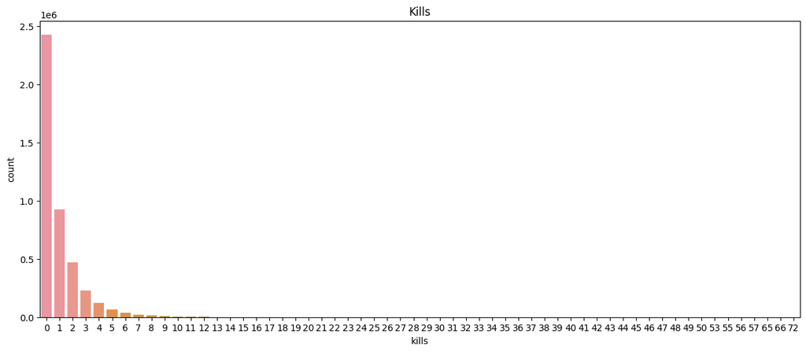

```python
plt.figure(figsize=(15,6))
sns.countplot(data=df, x=df['kills']).set_title('Kills')
plt.show()
```

```python
display(df[df['kills'] > 40].shape)
```

```
(32, 29)
```

```python
df[df['kills'] >= 40].head(5)
```

|  | Id | groupId | matchId | assists | boosts | damageDealt | DBNOs | headshotKills | heals | killPlace | killPoints | kills | killStreaks | longestKill | matchDuration | matchType | maxPlace | numGroups | rankPoints | revives | rideDistance | roadKills | swimDistance | teamKills | vehicleDestroys | walkDistance | weaponsAcquired | winPoints | winPlacePerc |
| --- | --- | --- | --- | --- | --- | --- | --- | --- | --- | --- | --- | --- | --- | --- | --- | --- | --- | --- | --- | --- | --- | --- | --- | --- | --- | --- | --- | --- | --- |
| 156599 | 746aa7eabf7c86 | 5723e7d8250da3 | f900de1ec39fa5 | 21 | 0 | 5480.0 | 0 | 12 | 7 | 4 | 0 | 48 | 6 | 81.9375 | 1798 | normal-solo-fpp | 11 | 11 | 1500 | 0 | 0.0 | 0 | 0.0 | 0 | 0 | 23.703125 | 61 | 0 | 0.700195 |
| 160254 | 15622257cb44e2 | 1a513eeecfe724 | db413c7c48292c | 1 | 0 | 4032.0 | 0 | 40 | 0 | 1 | 1000 | 42 | 5 | 266.2500 | 844 | normal-squad-fpp | 8 | 8 | -1 | 0 | 0.0 | 0 | 0.0 | 1 | 0 | 718.500000 | 16 | 1500 | 1.000000 |
| 334400 | 810f2379261545 | 7f3e493ee71534 | f900de1ec39fa5 | 20 | 0 | 6616.0 | 0 | 13 | 5 | 1 | 0 | 65 | 7 | 73.8750 | 1798 | normal-solo-fpp | 11 | 11 | 1500 | 0 | 0.0 | 0 | 0.0 | 0 | 0 | 1036.000000 | 60 | 0 | 1.000000 |
| 672993 | da31f191ace8ed | ce9a3c4950a8f2 | 17dea22cefe62a | 10 | 0 | 5792.0 | 0 | 5 | 2 | 1 | 0 | 57 | 5 | 104.1875 | 1798 | normal-duo-fpp | 15 | 12 | 1500 | 0 | 0.0 | 0 | 0.0 | 0 | 0 | 24.265625 | 56 | 0 | 1.000000 |
| 770454 | 2ade4369bccd12 | 9f9e64a3db8384 | e024bf51bf1799 | 12 | 0 | 5556.0 | 0 | 7 | 4 | 1 | 0 | 55 | 6 | 74.8125 | 1798 | normal-solo-fpp | 19 | 18 | 1500 | 0 | 0.0 | 0 | 0.0 | 0 | 0 | 85.562500 | 66 | 0 | 1.000000 |

It doesn't look like there are too many outliers. We decide to remove those.

```python
df.drop(df[df['kills'] >= 40].index, inplace=True)
largeKillsDropCount = len(df)
```

```python
print(largeKillsDropCount)
print("Dropped:", potentialCheatsDropCount - largeKillsDropCount)
```

```
4337436
Dropped: 36
```

#### Potential Aim Bot

We will create a new feature 'headshotRate' and plot of it

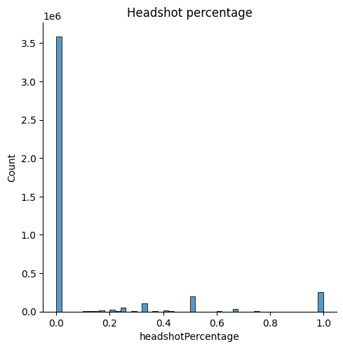

```python
df['headshotPercentage'] = df['headshotKills'] / df['kills']
df['headshotPercentage'] = df['headshotPercentage'].fillna(0)

plt.figure(figsize=(12, 4))
sns.displot(df['headshotPercentage'], bins=50)
plt.title('Headshot percentage')
plt.show()
```

Not every player with 100% headshot has to be cheater. They might be just goog players.n That's why we will remove only players who have more than 10 kills and 100% headshots.

```python
df[(df['headshotKills'] == df['kills']) & (df['kills'] >= 10)].head(5)
```

|  | Id | groupId | matchId | assists | boosts | damageDealt | DBNOs | headshotKills | heals | killPlace | killPoints | kills | killStreaks | longestKill | matchDuration | matchType | maxPlace | numGroups | rankPoints | revives | rideDistance | roadKills | swimDistance | teamKills | vehicleDestroys | walkDistance | weaponsAcquired | winPoints | winPlacePerc | … |
| --- | --- | --- | --- | --- | --- | --- | --- | --- | --- | --- | --- | --- | --- | --- | --- | --- | --- | --- | --- | --- | --- | --- | --- | --- | --- | --- | --- | --- | --- | --- |
| 281570 | ab9d7168570927 | add05ebde0214c | e016a873339c7b | 2 | 3 | 1212.0 | 8 | 10 | 0 | 1 | 0 | 10 | 4 | 159.25 | 1423 | squad-fpp | 27 | 25 | 1564 | 1 | 0.0 | 0 | 0.0 | 0 | 0 | 2940.0 | 5 | 0 | 0.846191 | … |
| 346124 | 044d18fc42fc75 | fc1dbc2df6a887 | 628107d4c41084 | 3 | 5 | 1620.0 | 13 | 11 | 3 | 1 | 1424 | 11 | 2 | 633.50 | 1727 | squad | 27 | 26 | -1 | 3 | 4720.0 | 0 | 0.0 | 0 | 0 | 3422.0 | 8 | 1560 | 1.000000 | … |
| 871244 | e668a25f5488e3 | 5ba8feabfb2a23 | f6e6581e03ba4f | 0 | 4 | 1365.0 | 9 | 13 | 0 | 1 | 1579 | 13 | 2 | 353.75 | 1255 | squad | 27 | 27 | -1 | 0 | 0.0 | 0 | 0.0 | 0 | 0 | 2104.0 | 5 | 1587 | 1.000000 | … |
| 908815 | 566d8218b705aa | a9b056478d71b2 | 3a41552d553583 | 2 | 5 | 1535.0 | 10 | 10 | 3 | 1 | 1393 | 10 | 3 | 533.00 | 1838 | squad-fpp | 28 | 24 | -1 | 0 | 5188.0 | 0 | 0.0 | 2 | 0 | 2760.0 | 7 | 1519 | 0.962891 | … |
| 963463 | 1bd6fd288df4f0 | 90584ffa22fe15 | ba2de992ec7bb8 | 2 | 6 | 1355.0 | 12 | 10 | 2 | 1 | 1543 | 10 | 2 | 277.00 | 1417 | squad | 27 | 26 | -1 | 0 | 1018.0 | 0 | 0.0 | 0 | 0 | 2458.0 | 4 | 1562 | 1.000000 | … |

```python
df.drop(df[(df['headshotKills'] == df['kills']) & (df['kills'] >= 10)].index, inplace=True)
highHSrateDropCount = len(df)
```

```python
print(highHSrateDropCount)
print("Dropped:", largeKillsDropCount - highHSrateDropCount)
```

```
4337412
Dropped: 24
```

Altogether we dropped

```python
print("Dropped:", validStartCount - highHSrateDropCount)
```

```
Dropped: 109553
```

## Train data and test data

Source of data: https://www.kaggle.com/c/pubg-finish-placement-prediction

Our data contains around 4.5 millions rows.

We are going to split it into two sets:

- train set,
- test set

```python
df_train, df_test = split_into_train_test_sets(df, 0.2)
```

### Train data

Brief look at the train data

```python
df_train.head()
```

|  | Id | groupId | matchId | assists | boosts | damageDealt | DBNOs | headshotKills | heals | killPlace | killPoints | kills | killStreaks | longestKill | matchDuration | matchType | maxPlace | numGroups | rankPoints | revives | rideDistance | roadKills | swimDistance | teamKills | vehicleDestroys | walkDistance | weaponsAcquired | winPoints | winPlacePerc | … |
| --- | --- | --- | --- | --- | --- | --- | --- | --- | --- | --- | --- | --- | --- | --- | --- | --- | --- | --- | --- | --- | --- | --- | --- | --- | --- | --- | --- | --- | --- | --- |
| 0 | 7f96b2f878858a | 4d4b580de459be | a10357fd1a4a91 | 0 | 0 | 0.00000 | 0 | 0 | 0 | 60 | 1241 | 0 | 0 | 0.00000 | 1306 | squad-fpp | 28 | 26 | -1 | 0 | 0.000000 | 0 | 0.000000 | 0 | 0 | 244.75 | 1 | 1466 | 0.444336 | … |
| 1 | eef90569b9d03c | 684d5656442f9e | aeb375fc57110c | 0 | 0 | 91.50000 | 0 | 0 | 0 | 57 | 0 | 0 | 0 | 0.00000 | 1777 | squad-fpp | 26 | 25 | 1484 | 0 | 0.004501 | 0 | 11.039062 | 0 | 0 | 1434.00 | 5 | 0 | 0.640137 | … |
| 2 | 1eaf90ac73de72 | 6a4a42c3245a74 | 110163d8bb94ae | 1 | 0 | 68.00000 | 0 | 0 | 0 | 47 | 0 | 0 | 0 | 0.00000 | 1318 | duo | 50 | 47 | 1491 | 0 | 0.000000 | 0 | 0.000000 | 0 | 0 | 161.75 | 2 | 0 | 0.775391 | … |
| 3 | 4616d365dd2853 | a930a9c79cd721 | f1f1f4ef412d7e | 0 | 0 | 32.90625 | 0 | 0 | 0 | 75 | 0 | 0 | 0 | 0.00000 | 1436 | squad-fpp | 31 | 30 | 1408 | 0 | 0.000000 | 0 | 0.000000 | 0 | 0 | 202.75 | 3 | 0 | 0.166748 | … |
| 4 | 315c96c26c9aac | de04010b3458dd | 6dc8ff871e21e6 | 0 | 0 | 100.00000 | 0 | 0 | 0 | 45 | 0 | 1 | 1 | 58.53125 | 1424 | solo-fpp | 97 | 95 | 1560 | 0 | 0.000000 | 0 | 0.000000 | 0 | 0 | 49.75 | 2 | 0 | 0.187500 | … |

```python
df_train.describe()
```

|  | assists | boosts | damageDealt | DBNOs | headshotKills | heals | killPlace | killPoints | kills | killStreaks | longestKill | matchDuration | maxPlace | numGroups | rankPoints | revives | rideDistance | roadKills | swimDistance | teamKills | vehicleDestroys | walkDistance | weaponsAcquired | winPoints | winPlacePerc | headshotPercentage |
| --- | --- | --- | --- | --- | --- | --- | --- | --- | --- | --- | --- | --- | --- | --- | --- | --- | --- | --- | --- | --- | --- | --- | --- | --- | --- | --- |
| count | 3.469847e+06 | 3.469847e+06 | 3.469847e+06 | 3.469847e+06 | 3.469847e+06 | 3.469847e+06 | 3.469847e+06 | 3.469847e+06 | 3.469847e+06 | 3.469847e+06 | 3.469847e+06 | 3.469847e+06 | 3.469847e+06 | 3.469847e+06 | 3.469847e+06 | 3.469847e+06 | 3469847.000 | 3.469847e+06 | 3469847.0 | 3.469847e+06 | 3.469847e+06 | 3.469847e+06 | 3.469847e+06 | 3.469847e+06 | 3.469847e+06 | 3.469847e+06 |
| mean | 2.383901e-01 | 1.131767e+00 | NaN | 6.718607e-01 | 2.316344e-01 | 1.402385e+00 | 4.682020e+01 | 5.064362e+02 | 9.446624e-01 | 5.557087e-01 | NaN | 1.580254e+03 | 4.450200e+01 | 4.304152e+01 | 8.922022e+02 | 1.682633e-01 | NaN | 3.084286e-03 | NaN | 2.396071e-02 | 7.964328e-03 | NaN | 3.734484e+00 | 6.076616e+02 | NaN | 1.054396e-01 |
| std | 5.927108e-01 | 1.727558e+00 | NaN | 1.153240e+00 | 6.027012e-01 | 2.705222e+00 | 2.705407e+01 | 6.284574e+02 | 1.561952e+00 | 7.132730e-01 | NaN | 2.572401e+02 | 2.377867e+01 | 2.321655e+01 | 7.368644e+02 | 4.768281e-01 | NaN | 6.590024e-02 | NaN | 1.680334e-01 | 9.259659e-02 | NaN | 2.415307e+00 | 7.404351e+02 | 0.000000e+00 | 2.628985e-01 |
| min | 0.000000e+00 | 0.000000e+00 | 0.000000e+00 | 0.000000e+00 | 0.000000e+00 | 0.000000e+00 | 1.000000e+00 | 0.000000e+00 | 0.000000e+00 | 0.000000e+00 | 0.000000e+00 | 1.330000e+02 | 2.000000e+00 | 1.000000e+00 | -1.000000e+00 | 0.000000e+00 | 0.000 | 0.000000e+00 | 0.0 | 0.000000e+00 | 0.000000e+00 | 1.000166e-04 | 0.000000e+00 | 0.000000e+00 | 0.000000e+00 | 0.000000e+00 |
| 25% | 0.000000e+00 | 0.000000e+00 | 0.000000e+00 | 0.000000e+00 | 0.000000e+00 | 0.000000e+00 | 2.300000e+01 | 0.000000e+00 | 0.000000e+00 | 0.000000e+00 | 0.000000e+00 | 1.367000e+03 | 2.800000e+01 | 2.700000e+01 | -1.000000e+00 | 0.000000e+00 | 0.000 | 0.000000e+00 | 0.0 | 0.000000e+00 | 0.000000e+00 | 1.722500e+02 | 2.000000e+00 | 0.000000e+00 | 2.143555e-01 | 0.000000e+00 |
| 50% | 0.000000e+00 | 0.000000e+00 | 8.818750e+01 | 0.000000e+00 | 0.000000e+00 | 0.000000e+00 | 4.700000e+01 | 0.000000e+00 | 0.000000e+00 | 0.000000e+00 | 0.000000e+00 | 1.438000e+03 | 3.000000e+01 | 3.000000e+01 | 1.444000e+03 | 0.000000e+00 | 0.000 | 0.000000e+00 | 0.0 | 0.000000e+00 | 0.000000e+00 | 7.340000e+02 | 3.000000e+00 | 0.000000e+00 | 4.680176e-01 | 0.000000e+00 |
| 75% | 0.000000e+00 | 2.000000e+00 | 1.897500e+02 | 1.000000e+00 | 0.000000e+00 | 2.000000e+00 | 7.000000e+01 | 1.174000e+03 | 1.000000e+00 | 1.000000e+00 | 2.231250e+01 | 1.851000e+03 | 4.900000e+01 | 4.700000e+01 | 1.500000e+03 | 0.000000e+00 | 81.625 | 0.000000e+00 | 0.0 | 0.000000e+00 | 0.000000e+00 | 2.009000e+03 | 5.000000e+00 | 1.495000e+03 | 7.500000e-01 | 0.000000e+00 |
| max | 1.700000e+01 | 3.300000e+01 | 4.240000e+03 | 3.900000e+01 | 2.700000e+01 | 7.300000e+01 | 1.010000e+02 | 2.170000e+03 | 3.900000e+01 | 1.800000e+01 | 1.094000e+03 | 2.237000e+03 | 1.000000e+02 | 1.000000e+02 | 5.910000e+03 | 3.200000e+01 | 29424.000 | 1.800000e+01 | 1980.0 | 1.200000e+01 | 5.000000e+00 | 9.984000e+03 | 2.360000e+02 | 2.013000e+03 | 1.000000e+00 | 1.000000e+00 |

### Test data

```python
df_test.head()
```

|  | Id | groupId | matchId | assists | boosts | damageDealt | DBNOs | headshotKills | heals | killPlace | killPoints | kills | killStreaks | longestKill | matchDuration | matchType | maxPlace | numGroups | rankPoints | revives | rideDistance | roadKills | swimDistance | teamKills | vehicleDestroys | walkDistance | weaponsAcquired | winPoints | winPlacePerc | … |
| --- | --- | --- | --- | --- | --- | --- | --- | --- | --- | --- | --- | --- | --- | --- | --- | --- | --- | --- | --- | --- | --- | --- | --- | --- | --- | --- | --- | --- | --- | --- |
| 7 | 311b84c6ff4390 | eaba5fcb7fc1ae | 292611730ca862 | 0 | 0 | 8.539062 | 0 | 0 | 0 | 48 | 1000 | 0 | 0 | 0.000000 | 1967 | solo-fpp | 96 | 92 | -1 | 0 | 2004.0 | 0 | 0.00000 | 0 | 0 | 1089.00 | 6 | 1500 | 0.736816 | … |
| 19 | 71cbdbc3b263e5 | 7b61f74b51906c | a329ac99449ad7 | 0 | 1 | 65.250000 | 0 | 0 | 1 | 48 | 1349 | 0 | 0 | 0.000000 | 1322 | squad-fpp | 30 | 28 | 0 | 0 | 0.0 | 0 | 20.84375 | 0 | 0 | 3310.00 | 3 | 1479 | 0.931152 | … |
| 28 | f9473c4f1cfdc4 | 8483976f3ba230 | 6057f846f3ed12 | 0 | 6 | 345.500000 | 2 | 1 | 1 | 6 | 0 | 4 | 1 | 105.187500 | 1339 | squad-fpp | 28 | 28 | 1339 | 0 | 0.0 | 0 | 0.00000 | 0 | 0 | 3856.00 | 4 | 0 | 0.962891 | … |
| 35 | 47143f942503e0 | e17a8867a393ec | bc2faecb77e5ec | 0 | 0 | 136.875000 | 0 | 0 | 0 | 37 | 0 | 1 | 1 | 22.828125 | 1425 | solo-fpp | 96 | 94 | 1500 | 0 | 0.0 | 0 | 0.00000 | 0 | 0 | 270.75 | 1 | 0 | 0.347412 | … |
| 40 | ffd9e56f13438e | 8df2112760f9e2 | 3f8b160eeee685 | 0 | 1 | 61.906250 | 1 | 0 | 1 | 31 | 0 | 1 | 1 | 48.406250 | 1303 | squad | 26 | 25 | 1472 | 0 | 529.0 | 0 | 0.00000 | 0 | 0 | 327.25 | 2 | 0 | 0.320068 | … |

```python
df_test.describe()
```

|  | assists | boosts | damageDealt | DBNOs | headshotKills | heals | killPlace | killPoints | kills | killStreaks | longestKill | matchDuration | maxPlace | numGroups | rankPoints | revives | rideDistance | roadKills | swimDistance | teamKills | vehicleDestroys | walkDistance | weaponsAcquired | winPoints | winPlacePerc | headshotPercentage |
| --- | --- | --- | --- | --- | --- | --- | --- | --- | --- | --- | --- | --- | --- | --- | --- | --- | --- | --- | --- | --- | --- | --- | --- | --- | --- | --- |
| count | 867565.000000 | 867565.000000 | 867565.000 | 867565.000000 | 867565.000000 | 867565.000000 | 867565.000000 | 867565.000000 | 867565.000000 | 867565.000000 | 867565.000000 | 867565.000000 | 867565.000000 | 867565.000000 | 867565.000000 | 867565.000000 | 867565.0000 | 867565.000000 | 867565.0 | 867565.000000 | 867565.000000 | 867565.0000 | 867565.000000 | 867565.000000 | 867565.000000 | 867565.000000 |
| mean | 0.238522 | 1.131575 | NaN | 0.675299 | 0.231425 | 1.392457 | 46.833276 | 515.209303 | 0.940653 | 0.556460 | NaN | 1580.545062 | 44.283254 | 42.829447 | 880.640411 | 0.169433 | NaN | 0.003108 | NaN | 0.023577 | 0.008021 | NaN | 3.720321 | 618.834212 | NaN | 0.105714 |
| std | 0.587974 | 1.724802 | NaN | 1.147718 | 0.600599 | 2.686267 | 27.049054 | 629.828682 | 1.542626 | 0.714488 | NaN | 257.405717 | 23.582118 | 23.000790 | 738.636207 | 0.476911 | NaN | 0.065496 | NaN | 0.165959 | 0.093134 | NaN | 2.352038 | 742.563683 | 0.000000 | 0.263227 |
| min | 0.000000 | 0.000000 | 0.000 | 0.000000 | 0.000000 | 0.000000 | 1.000000 | 0.000000 | 0.000000 | 0.000000 | 0.000000 | 312.000000 | 2.000000 | 1.000000 | -1.000000 | 0.000000 | 0.0000 | 0.000000 | 0.0 | 0.000000 | 0.000000 | 0.0001 | 0.000000 | 0.000000 | 0.000000 | 0.000000 |
| 25% | 0.000000 | 0.000000 | 0.000 | 0.000000 | 0.000000 | 0.000000 | 23.000000 | 0.000000 | 0.000000 | 0.000000 | 0.000000 | 1367.000000 | 28.000000 | 27.000000 | -1.000000 | 0.000000 | 0.0000 | 0.000000 | 0.0 | 0.000000 | 0.000000 | 171.7500 | 2.000000 | 0.000000 | 0.214355 | 0.000000 |
| 50% | 0.000000 | 0.000000 | 88.750 | 0.000000 | 0.000000 | 0.000000 | 47.000000 | 0.000000 | 0.000000 | 0.000000 | 0.000000 | 1438.000000 | 30.000000 | 30.000000 | 1438.000000 | 0.000000 | 0.0000 | 0.000000 | 0.0 | 0.000000 | 0.000000 | 731.5000 | 3.000000 | 0.000000 | 0.466797 | 0.000000 |
| 75% | 0.000000 | 2.000000 | 189.625 | 1.000000 | 0.000000 | 2.000000 | 70.000000 | 1178.000000 | 1.000000 | 1.000000 | 22.296875 | 1851.000000 | 49.000000 | 47.000000 | 1500.000000 | 0.000000 | 59.6875 | 0.000000 | 0.0 | 0.000000 | 0.000000 | 2011.0000 | 5.000000 | 1497.000000 | 0.750000 | 0.000000 |
| max | 17.000000 | 23.000000 | 4080.000 | 26.000000 | 23.000000 | 80.000000 | 100.000000 | 2154.000000 | 38.000000 | 11.000000 | 1000.000000 | 2218.000000 | 100.000000 | 100.000000 | 5820.000000 | 39.000000 | 28448.0000 | 11.000000 | 1960.0 | 4.000000 | 3.000000 | 9992.0000 | 95.000000 | 2002.000000 | 1.000000 | 1.000000 |

### Data Fields Descriptions

```python
print(df_types)
```

```
         Data field                                        Description     Type
0                Id                                        Player's Id   object
1           groupId              ID to identify a group within a match   object
2           matchId                               ID to identify match   object
3         matchType  String identifing the game mode that the data ...   object
4           assists  Number of enemy players this player damaged th...    int64
5            boosts                         Number of boost items used    int64
6       damageDealt                                 Total damage dealt  float64
7             DBNOs                    Number of enemy players knocked    int64
8     headshotKills      Number of enemy players killed with headshots    int64
9             heals                       Number of healing items used    int64
10        killPlace  Ranking in match of number of enemy players ki...    int64
11       killPoints             Kills-based external ranking of player    int64
12      killStreaks  Max number of enemy players killed in a short ...    int64
13            kills                     Number of enemy players killed    int64
14      longestKill  Longest distance between player and player kil...  float64
15    matchDuration                       Duration of match in seconds    int64
16       rankPoints                         Elo-like ranking of player    int64
17          revives      Number of times this player revived teammates    int64
18     rideDistance  Total distance traveled in vehicles measured i...    int64
19        roadKills                 Number of kills while in a vehicle    int64
20     swimDistance  Total distance traveled by swimming measured i...  float64
21        teamKills      Number of times this player killed a teammate    int64
22  vehicleDestroys                       Number of vehicles destroyed    int64
23     walkDistance  Total distance traveled on foot measured in me...  float64
24  weaponsAcquired                        Number of weapons picked up    int64
25        winPoints               Win-based external ranking of player    int64
26        numGroups     Number of groups we have data for in the match    int64
27         maxPlace      Worst placement we have data for in the match    int64
28     winPlacePerc                           The target of prediction  float64
```

```python
print(df_train["matchType"].unique())
```

```
['squad-fpp' 'duo' 'solo-fpp' 'squad' 'duo-fpp' 'solo' 'normal-squad-fpp'
 'normal-solo-fpp' 'normal-duo-fpp' 'normal-duo' 'normal-squad'
 'normal-solo']
```

Players playing solo-match have their own placement, while the players from the same group share the same placement.

## Looking for best strategy

### Correlation of feature

A correlation matrix is a table showing correlation coefficients between variables. Each cell in the table shows the correlation between two variables.

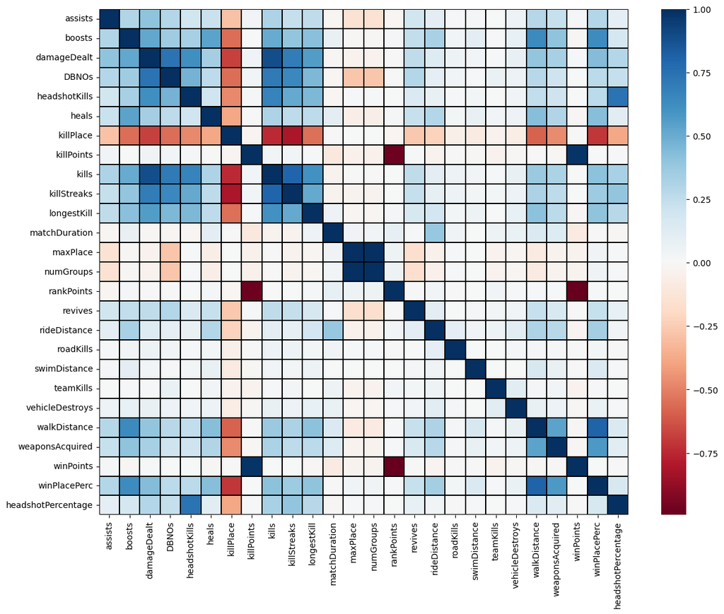

```python
# We do not use columns containing Id and matchType. Only numerical values.
cols_to_drop = ['Id', 'groupId', 'matchId', 'matchType']
cols_to_fit = [col for col in df.columns if col not in cols_to_drop]
corr = df[cols_to_fit].corr()

plt.figure(figsize=(14,11))
sns.heatmap(
    corr,
    xticklabels=corr.columns.values,
    yticklabels=corr.columns.values,
    linecolor='black',
    linewidths=0.1,
    cmap="RdBu"
)
plt.show()
```

Pairs with correlation >= 0.45:

```python
corr_pairs = corr.unstack().sort_values(ascending=False).drop_duplicates()
corr_pairs[corr_pairs >= 0.45]
```

```
assists             assists          1.000000
maxPlace            numGroups        0.998236
winPoints           killPoints       0.983452
damageDealt         kills            0.887425
winPlacePerc        walkDistance     0.810390
kills               killStreaks      0.803082
damageDealt         DBNOs            0.737639
headshotPercentage  headshotKills    0.737256
kills               DBNOs            0.709956
killStreaks         damageDealt      0.701581
kills               headshotKills    0.671712
killStreaks         DBNOs            0.644889
boosts              walkDistance     0.637142
winPlacePerc        boosts           0.632603
headshotKills       damageDealt      0.610699
kills               longestKill      0.603579
weaponsAcquired     winPlacePerc     0.573229
damageDealt         longestKill      0.563338
weaponsAcquired     walkDistance     0.537947
boosts              heals            0.532803
                    damageDealt      0.521317
killStreaks         longestKill      0.512229
                    headshotKills    0.511868
kills               boosts           0.502377
DBNOs               headshotKills    0.470472
dtype: float64
```

#### Highlt correlated

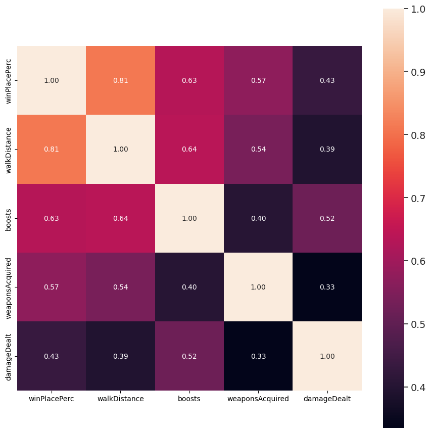

```python
f,ax = plt.subplots(figsize=(11, 11))
cols = df.corr().nlargest(5, 'winPlacePerc')['winPlacePerc'].index
cm = np.corrcoef(df[cols].values.T)
sns.set(font_scale=1.25)
hm = sns.heatmap(cm, cbar=True, annot=True, square=True, fmt='.2f', annot_kws={'size': 10}, yticklabels=cols.values, xticklabels=cols.values)
plt.show()
```

### Impact of kills made on final position

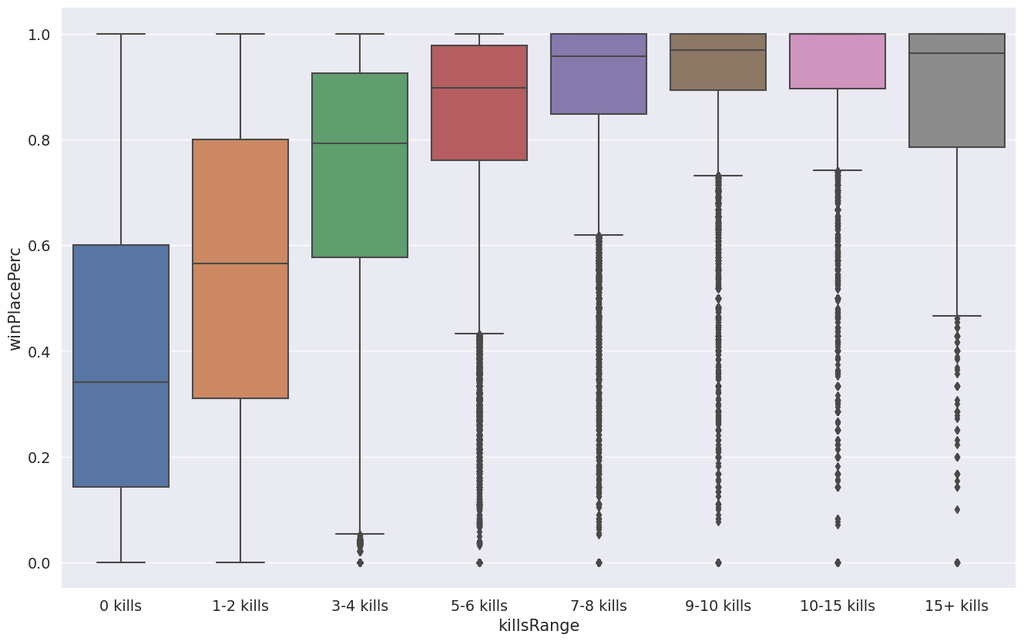

```python
df['killsRange'] = pd.cut(df['kills'], [-1, 0, 2, 4, 6, 8, 10, 15, 100],
                                            labels=['0 kills','1-2 kills', '3-4 kills', '5-6 kills',
                                                    '7-8 kills', '9-10 kills','10-15 kills', '15+ kills'])
plt.figure(figsize=(16,10))
sns.boxplot(x='killsRange', y='winPlacePerc', data=df)
df.drop(['killsRange'],axis=1,inplace=True)
```

### Boosts and heals importance

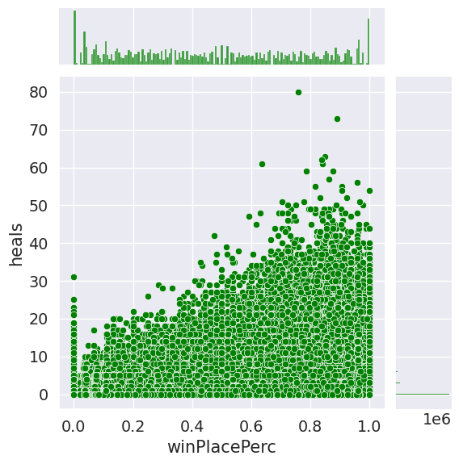

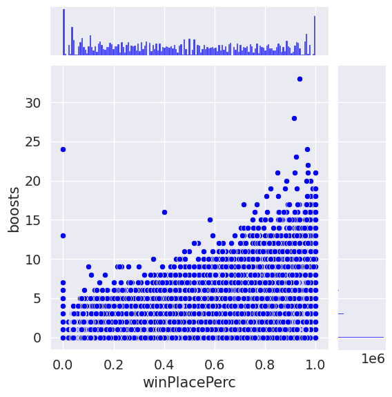

```python
sns.jointplot(x='winPlacePerc', y='heals', data=df, color='green')
sns.jointplot(x='winPlacePerc', y='boosts', data=df, color='blue')
plt.show()
```

## New Features

Now we will consider some other options.

### Players in match

This features will let as know how many people are in a match. Thanks to that we can normalize some features.

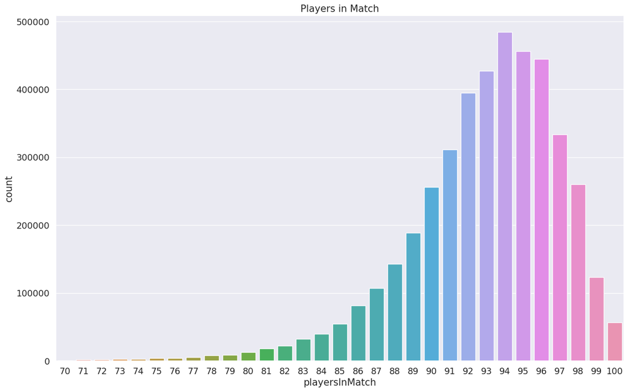

```python
df['playersInMatch'] = df.groupby('matchId')['matchId'].transform('count')
plt.figure(figsize=(16,10))
sns.countplot(x=df[df['playersInMatch']>=70]['playersInMatch'])
plt.title('Players in Match')
plt.show()
```

Most of the matches are nearly full.

#### Normalization

Based on the "playersInMatch" feature we can create (or change) a lot of others to normalize their values. Since the number of players in game is not const and when there are 100players in the game it might be easier to find someone we can create the "killsNorm", "damageDealtNorm"

```python
df['killsNorm'] = df['kills']*((100-df['playersInMatch'])/100 + 1)
df['damageDealtNorm'] = df['damageDealt']*((100-df['playersInMatch'])/100 + 1)
df['assistsNorm'] = df['assists']*((100-df['playersInMatch'])/100 + 1)
df['DBNOsNorm'] = df['DBNOs']*((100-df['playersInMatch'])/100 + 1)

df[['playersInMatch', 'kills', 'killsNorm', 'damageDealt', 'damageDealtNorm', 'assists', 'assistsNorm', 'DBNOs', 'DBNOsNorm']].head()
```

|  | playersInMatch | kills | killsNorm | damageDealt | damageDealtNorm | assists | assistsNorm | DBNOs | DBNOsNorm |
| --- | --- | --- | --- | --- | --- | --- | --- | --- | --- |
| 0 | 94 | 0 | 0.00 | 0.00000 | 0.000000 | 0 | 0.00 | 0 | 0.0 |
| 1 | 90 | 0 | 0.00 | 91.50000 | 100.650000 | 0 | 0.00 | 0 | 0.0 |
| 2 | 93 | 0 | 0.00 | 68.00000 | 72.760000 | 1 | 1.07 | 0 | 0.0 |
| 3 | 91 | 0 | 0.00 | 32.90625 | 35.867812 | 0 | 0.00 | 0 | 0.0 |
| 4 | 94 | 1 | 1.06 | 100.00000 | 106.000000 | 0 | 0.00 | 0 | 0.0 |

### Total Distance

```python
df['totalDistance'] = df['rideDistance'] + df['swimDistance'] + df['walkDistance']
df['totalDistance'].describe()
```

```
count    4.337412e+06
mean              NaN
std               NaN
min      1.000166e-04
25%      1.755000e+02
50%      8.560000e+02
75%      2.770000e+03
max      3.030400e+04
Name: totalDistance, dtype: float64
```

## New Features Evaluation |For 21.04

We will create new features and analyze their impact. To do that we will create a simple linear model for each set of features and compare them.

```python
from sklearn.linear_model import LinearRegression, Lasso, ElasticNet
from sklearn.neural_network import MLPRegressor
from sklearn.metrics import mean_absolute_error, mean_squared_error, explained_variance_score
from sklearn.model_selection import cross_val_score, GridSearchCV
from sklearn.feature_selection import SelectFromModel
from sklearn.ensemble import RandomForestRegressor
```

### Linear Regression

```python
results = []
def resultsAppend(name,val):
    results.append({'name': name, 'error': val} )
```

```python
colsToDrop = ['Id','groupId','matchId','matchType']
colsNorm = ['killsNorm','damageDealtNorm','assistsNorm','DBNOsNorm']
colsNoNorm = ['kills', 'damageDealt','assists', 'DBNOs']
```

```python
def scoreMetrices(true,predicted):
      return (mean_squared_error(true,predicted),)
```

```python
def tryDataLinear(data):
    random.seed(42)
    data_train,data_test = split_into_train_test_sets(data)
    data_train = data_train.drop(colsToDrop,axis=1)
    data_test = data_test.drop(colsToDrop,axis=1)

    model = LinearRegression(n_jobs=-1)
    model.fit(data_train.drop(['winPlacePerc'],axis=1),data_train['winPlacePerc'])
    pred = model.predict(data_test.drop(['winPlacePerc'],axis=1))
    return scoreMetrices(data_test['winPlacePerc'],pred)
```

We are checking already added features.

```python
results = []
resultsAppend('default', tryDataLinear(df[defaultCols]))
resultsAppend('normalized w/', tryDataLinear(df[defaultCols + colsNorm]))
resultsAppend('normalized w/o', tryDataLinear(df[defaultCols + colsNorm].drop(colsNoNorm,axis=1)))
resultsAppend('total distance', tryDataLinear(df[defaultCols + ['totalDistance']]))
resultsAppend('hs percentage', tryDataLinear(df[defaultCols + ['headshotPercentage']]))
```

We are adding new features.

```python
df['items'] = df['heals'] + df['boosts']
resultsAppend('items', tryDataLinear(df[defaultCols+['items']]))
```

```python
df['walkDistancePerKill'] = df['walkDistance'] / df['kills']
df['walkDistancePerKill'].fillna(0, inplace=True)
df['walkDistancePerKill'].replace(np.inf, 0, inplace=True)
resultsAppend('walk dist per kill', tryDataLinear(df[defaultCols+['walkDistancePerKill']]))
```

```python
resultsAppend('all', tryDataLinear(df))
```

```python
gc.collect()
pd.DataFrame(results)
```

|  | name | error |
| --- | --- | --- |
| 0 | default | 0.015742 |
| 1 | normalized w/ | 0.015623 |
| 2 | normalized w/o | 0.015760 |
| 3 | total distance | 0.015742 |
| 4 | hs percentage | 0.015472 |
| 5 | items | 0.015742 |
| 6 | walk dist per kill | 0.015717 |
| 7 | all | 0.014732 |

We can see that all added features separately have little to no effect on MSE value but combined they decrease error value.

### Random Forrest

We are going to create simple Random Forrest Regressor model on all added features and extract their importances.

```python
def tryDataRandomFor(data):
    random.seed(42)
    data_train,data_test = split_into_train_test_sets(data)
    data_train = data_train.drop(colsToDrop,axis=1)
    data_test = data_test.drop(colsToDrop,axis=1)

    model = RandomForestRegressor(max_depth=20, random_state = 123, n_estimators=50,max_features='sqrt',verbose=1,n_jobs=-1)
    model.fit(data_train.drop(['winPlacePerc'],axis=1),data_train['winPlacePerc'])
    print("ready, predicting...")
    pred = model.predict(data_test.drop(['winPlacePerc'],axis=1))
    gc.collect()
    print(model.feature_importances_)
    return scoreMetrices(data_test['winPlacePerc'],pred),model.feature_importances_
```

```python
err, importances = tryDataRandomFor(df)
err
```

```
[Parallel(n_jobs=-1)]: Using backend ThreadingBackend with 4 concurrent workers.
[Parallel(n_jobs=-1)]: Done  42 tasks      | elapsed:  1.9min
[Parallel(n_jobs=-1)]: Done  50 out of  50 | elapsed:  2.2min finished
[Parallel(n_jobs=4)]: Using backend ThreadingBackend with 4 concurrent workers.
```

```
ready, predicting...
```

```
[Parallel(n_jobs=4)]: Done  42 tasks      | elapsed:    4.4s
[Parallel(n_jobs=4)]: Done  50 out of  50 | elapsed:    5.1s finished
```

```
[1.96188931e-03 9.49342500e-02 8.05289155e-03 1.63502346e-03
 9.24685222e-04 3.06395964e-02 2.07024049e-01 1.17194793e-03
 5.31039372e-03 2.56074178e-03 1.81659757e-02 1.54229028e-02
 8.48489584e-03 9.35906241e-03 2.18529340e-03 4.49193914e-04
 1.48008009e-02 3.14675069e-05 8.81232136e-04 1.81357033e-04
 5.72665215e-05 2.22661189e-01 6.45127010e-02 1.47509165e-03
 3.80463817e-03 6.97336086e-03 9.41051445e-03 1.15130708e-02
 1.87083502e-03 3.32803454e-03 1.58965349e-01 4.45503803e-02
 4.66999179e-02]
```

```
0.007329174284615545
```

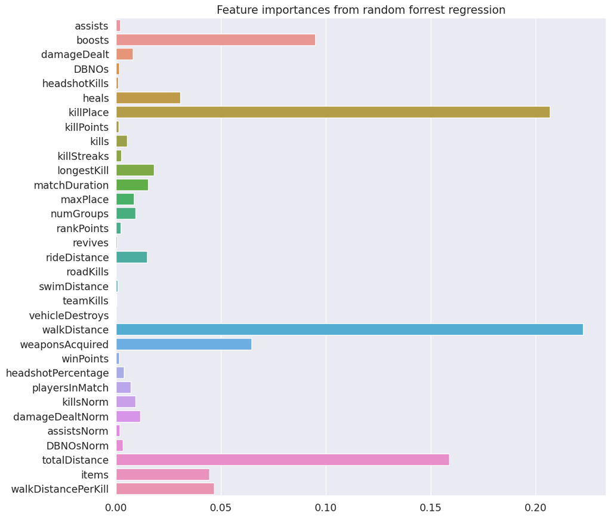

|  | importance |
| --- | --- |
| walkDistance | 0.222661 |
| killPlace | 0.207024 |
| totalDistance | 0.158965 |
| boosts | 0.094934 |
| weaponsAcquired | 0.064513 |
| walkDistancePerKill | 0.046700 |
| items | 0.044550 |
| heals | 0.030640 |
| longestKill | 0.018166 |
| matchDuration | 0.015423 |
| rideDistance | 0.014801 |
| damageDealtNorm | 0.011513 |
| killsNorm | 0.009411 |
| numGroups | 0.009359 |
| maxPlace | 0.008485 |
| damageDealt | 0.008053 |
| playersInMatch | 0.006973 |
| kills | 0.005310 |
| headshotPercentage | 0.003805 |
| DBNOsNorm | 0.003328 |
| killStreaks | 0.002561 |
| rankPoints | 0.002185 |
| assists | 0.001962 |
| assistsNorm | 0.001871 |
| DBNOs | 0.001635 |
| winPoints | 0.001475 |
| killPoints | 0.001172 |
| headshotKills | 0.000925 |
| swimDistance | 0.000881 |
| revives | 0.000449 |
| teamKills | 0.000181 |
| vehicleDestroys | 0.000057 |
| roadKills | 0.000031 |

```python
forest_importances = pd.DataFrame(importances, index = list(df.drop(['winPlacePerc']+colsToDrop,axis=1).columns),columns=["importance"])

plt.figure(figsize=(12,12))
ax = sns.barplot(y =list(df.drop(['winPlacePerc']+colsToDrop,axis=1).columns), x = importances)
plt.title('Feature importances from random forrest regression')
plt.show()
forest_importances.sort_values(by=['importance'],ascending=False)
```

### Multi-Layer Perceptron

We are adding a MLP model in order to check how well it performs compared to previously created models.

```python
def tryDataMLP(data):
    random.seed(13)
    data_train,data_test = split_into_train_test_sets(data)
    data_train = data_train.drop(colsToDrop,axis=1)
    data_test = data_test.drop(colsToDrop,axis=1)

    model = MLPRegressor(hidden_layer_sizes=(100,50),verbose=True)

    model.fit(data_train.drop(['winPlacePerc'],axis=1),data_train['winPlacePerc'])
    pred = model.predict(data_test.drop(['winPlacePerc'],axis=1))
    gc.collect()
    return scoreMetrices(data_test['winPlacePerc'],pred)
```

```python
tryDataMLP(df)
```

```
Iteration 1, loss = 12.30300443
Iteration 2, loss = 0.44146175
Iteration 3, loss = 0.03553147
Iteration 4, loss = 0.00599401
Iteration 5, loss = 0.00521973
Iteration 6, loss = 0.00474776
Iteration 7, loss = 0.00444030
Iteration 8, loss = 0.00440045
Iteration 9, loss = 0.00439647
Iteration 10, loss = 0.00438827
Iteration 11, loss = 0.00438111
Iteration 12, loss = 0.00437673
Iteration 13, loss = 0.00437625
Iteration 14, loss = 0.00437320
Iteration 15, loss = 0.00437158
Iteration 16, loss = 0.00436945
Iteration 17, loss = 0.00437131
Iteration 18, loss = 0.00437096
Training loss did not improve more than tol=0.000100 for 10 consecutive epochs. Stopping.
```

```
0.008658087505028349
```

The MSE value is comparable to Random Forrest Regressor error value. We also checked wider and deeper MLP models but no significant decrease in error value was achived.

### LightGBM | For 26.04

Next we will use tree based Light Gradient Boosting Machine model to see if we can still increase the performance.

LightGBM, unlike standard gradient boosting machines, uses growth in the vertical direction (leaf-wise) instead of growth in the horizontal direction (level-wise). Thanks to it model increases training speed and accuracy of received results for big volumes of data.

```python
def tryDataLGBM(data):
    # random.seed(13)
    data_train, data_test = split_into_train_test_sets(data)
    data_train = data_train.drop(colsToDrop, axis=1)
    data_test = data_test.drop(colsToDrop, axis=1)

    x_train = data_train.drop(['winPlacePerc'],axis=1)
    y_train = data_train['winPlacePerc']
    x_test = data_test.drop(['winPlacePerc'],axis=1)
    y_test = data_test['winPlacePerc']

    # laoding data
    lgb_train = lgb.Dataset(x_train, y_train)
    lgb_eval = lgb.Dataset(x_test, y_test, reference=lgb_train)

    params = {
        'objective': 'regression',    # defines regression model
        'num_leaves': 50,             # max number of leafs in one tree
        'learning_rate': 0.03,        # shrinkage rate - rate of dropped trees
        'min_split_gain': 0.0001,     # min gain to perform split
        'bagging_fraction': 0.9,      # randomly select subset of features on each iteration (without resampling)
        'min_data_in_leaf': 1000,     # min data in leaf
        'lambda_l2': 9,               # L2 regularization
        'metric': {'l2','l1'},        # list l1 (absolute loss) and l2 (square loss) metrics
    }

    # fitting the model
    # parameters:
    # num_boost_round - maximum number of boosting iterations
    # early_stopping - stopping after X iterations without notable increase
    # log_evaluation - write down evaluation results every X iterations
    model = lgb.train(params,
                      train_set=lgb_train,
                      valid_sets=lgb_eval,
                      num_boost_round = 1000,
                      callbacks=[lgb.early_stopping(stopping_rounds=30),
                                lgb.log_evaluation(period=100)])

    # prediction
    pred = model.predict(x_test)

    # accuracy check
    mse = mean_squared_error(y_test, pred)
    rmse = mse**(0.5)
    print("MSE: %.8f" % mse)
    print("RMSE: %.8f" % rmse)

    feature_importances_ = (model.feature_importance() / sum(model.feature_importance()))

    return scoreMetrices(data_test['winPlacePerc'], pred), feature_importances_
```

```python
err, importances = tryDataLGBM(df)
print("ERR: %f" % err)
```

```
[LightGBM] [Warning] Auto-choosing row-wise multi-threading, the overhead of testing was 0.240409 seconds.
You can set `force_row_wise=true` to remove the overhead.
And if memory is not enough, you can set `force_col_wise=true`.
[LightGBM] [Info] Total Bins 4510
[LightGBM] [Info] Number of data points in the train set: 3469771, number of used features: 33
[LightGBM] [Info] Start training from score 0.482656
Training until validation scores don't improve for 30 rounds
[100]	valid_0's l1: 0.0652805	valid_0's l2: 0.00790295
[200]	valid_0's l1: 0.0587909	valid_0's l2: 0.00673547
[300]	valid_0's l1: 0.0574327	valid_0's l2: 0.00645155
[400]	valid_0's l1: 0.0568812	valid_0's l2: 0.00633338
[500]	valid_0's l1: 0.0565826	valid_0's l2: 0.00627215
[600]	valid_0's l1: 0.0563721	valid_0's l2: 0.00623257
[700]	valid_0's l1: 0.0562298	valid_0's l2: 0.00620531
[800]	valid_0's l1: 0.0561374	valid_0's l2: 0.00618638
[900]	valid_0's l1: 0.0560596	valid_0's l2: 0.00617229
[1000]	valid_0's l1: 0.0559976	valid_0's l2: 0.00616046
Did not meet early stopping. Best iteration is:
[1000]	valid_0's l1: 0.0559976	valid_0's l2: 0.00616046
MSE: 0.00616046
RMSE: 0.07848859
ERR: 0.006160
```

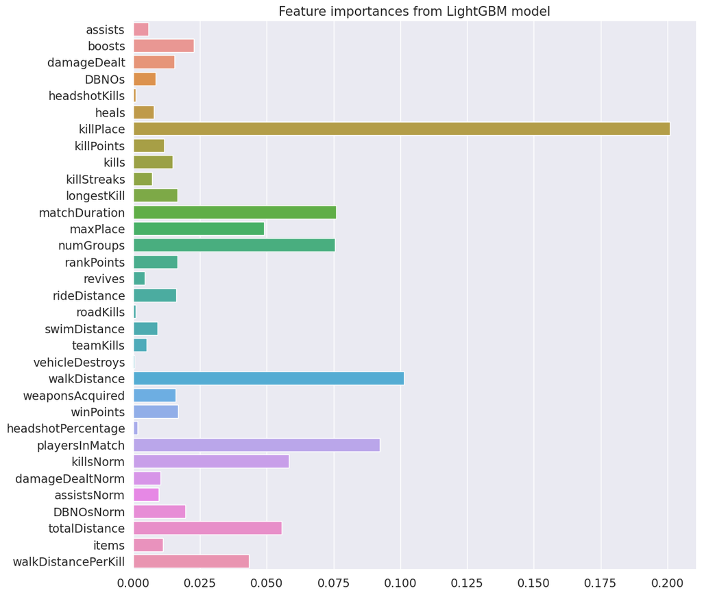

|  | importance |
| --- | --- |
| killPlace | 0.200878 |
| walkDistance | 0.101449 |
| playersInMatch | 0.092245 |
| matchDuration | 0.075959 |
| numGroups | 0.075571 |
| killsNorm | 0.058204 |
| totalDistance | 0.055571 |
| maxPlace | 0.049041 |
| walkDistancePerKill | 0.043245 |
| boosts | 0.022755 |
| DBNOsNorm | 0.019429 |
| winPoints | 0.016694 |
| rankPoints | 0.016612 |
| longestKill | 0.016490 |
| rideDistance | 0.016184 |
| weaponsAcquired | 0.015980 |
| damageDealt | 0.015367 |
| kills | 0.014735 |
| killPoints | 0.011571 |
| items | 0.011020 |
| damageDealtNorm | 0.010265 |
| assistsNorm | 0.009469 |
| swimDistance | 0.009041 |
| DBNOs | 0.008347 |
| heals | 0.007694 |
| killStreaks | 0.007061 |
| assists | 0.005755 |
| teamKills | 0.005102 |
| revives | 0.004388 |
| headshotPercentage | 0.001612 |
| roadKills | 0.001000 |
| headshotKills | 0.000816 |
| vehicleDestroys | 0.000449 |

```python
LGBM_importances = pd.DataFrame(importances, index = list(df.drop(['winPlacePerc']+colsToDrop,axis=1).columns),columns=["importance"])

plt.figure(figsize=(12,12))
ax = sns.barplot(y =list(df.drop(['winPlacePerc']+colsToDrop,axis=1).columns), x = importances)
plt.title('Feature importances from LightGBM model')
plt.show()
LGBM_importances.sort_values(by=['importance'],ascending=False)
```

Model is defined in sklearn.tree namespace

```python
from sklearn.tree import DecisionTreeRegressor
```

While defining model, only parameter that we provide is maximal depth of trees - we use 10, as it significantly improves accuracy of algorithm.

```python
def tryDataGBRT(data):
    data_train,data_test = split_into_train_test_sets(data)
    data_train = data_train.drop(colsToDrop,axis=1)
    data_test = data_test.drop(colsToDrop,axis=1)
    model = DecisionTreeRegressor(max_depth=10)
    model.fit(data_train.drop(['winPlacePerc'],axis=1),data_train['winPlacePerc'])
    pred = model.predict(data_test.drop(['winPlacePerc'],axis=1))
    gc.collect()
    return scoreMetrices(data_test['winPlacePerc'],pred)
```

```python
err = tryDataGBRT(df)
print("ERR: %f" % err)
```

```
ERR: 0.009002
```

### XGboost

XGBoost is an open-source library providing implementation of gradient boosted decision trees algorithm. This library provies regression model, we will use model from scikit-learn wrapper classes.

First of all we need to import the necessary library and valid regression model from it

```python
import xgboost
from xgboost import XGBRegressor
```

XGBRegressor is a class from scikit-learn, it is parameterizable. We specify the following parameters:

```python
def tryDataXGBoost(data):
    data_train,data_test = split_into_train_test_sets(data)
    data_train = data_train.drop(colsToDrop,axis=1)
    data_test = data_test.drop(colsToDrop,axis=1)
    model = XGBRegressor(n_estimators=100, max_depth=5, eta=0.1, subsample=1, colsample_bytree=1)
    model.fit(data_train.drop(['winPlacePerc'],axis=1),data_train['winPlacePerc'])
    pred = model.predict(data_test.drop(['winPlacePerc'],axis=1))
    gc.collect()
    return scoreMetrices(data_test['winPlacePerc'],pred)
```

```python
err = tryDataXGBoost(df)
print("ERR: %f" % err)
```

```
ERR: 0.006813
```

# PUBG Finish Placement Prediction

```python
# Imports
import sys
import pandas as pd
import numpy as np
import matplotlib.pyplot as plt
import seaborn as sns
import lightgbm as lgb
import random
import gc
import graphviz

random.seed(16)
```

```python
# Read data to dataframe
df = pd.read_csv("data/train_V2.csv")
df_types = pd.read_csv("data/types.csv")
```

```python
# Initial settings
pd.set_option('display.max_rows',500)
pd.set_option('display.max_columns',500)
pd.set_option('display.width',2000)

plt.rcParams['figure.dpi'] = 100
```

```python
#center figures
from IPython.core.display import HTML
HTML("""
<style>
.output_png {
    display: table-cell;
    text-align: center;
    vertical-align: middle;
}
</style>
""")
```

```python
# Memory saving function credit to https://www.kaggle.com/gemartin/load-data-reduce-memory-usage
def reduce_mem_usage(df):
    for col in df.columns:
        col_type = df[col].dtype

        if col_type != object:
            c_min = df[col].min()
            c_max = df[col].max()
            if str(col_type)[:3] == 'int':
                if c_min > np.iinfo(np.int8).min and c_max < np.iinfo(np.int8).max:
                    df[col] = df[col].astype(np.int8)
                elif c_min > np.iinfo(np.int16).min and c_max < np.iinfo(np.int16).max:
                    df[col] = df[col].astype(np.int16)
                elif c_min > np.iinfo(np.int32).min and c_max < np.iinfo(np.int32).max:
                    df[col] = df[col].astype(np.int32)
                elif c_min > np.iinfo(np.int64).min and c_max < np.iinfo(np.int64).max:
                    df[col] = df[col].astype(np.int64)
            else:
                if c_min > np.finfo(np.float16).min and c_max < np.finfo(np.float16).max:
                    df[col] = df[col].astype(np.float16)
                elif c_min > np.finfo(np.float32).min and c_max < np.finfo(np.float32).max:
                    df[col] = df[col].astype(np.float32)
                else:
                    df[col] = df[col].astype(np.float64)
    return df
```

```python
# Reducing memory usage
print(str(sys.getsizeof(df)/1024/1024) + " MB")
df = reduce_mem_usage(df)
df_types = reduce_mem_usage(df_types)
print(str(sys.getsizeof(df)/1024/1024) + " MB")
```

```
2024.0970821380615 MB
1328.5800914764404 MB
```

```python
# Function to split data into two sets
# Data is grouped by "matchId" which means that games are not mixed up between sets.

def split_into_train_test_sets(df, test_set_size=0.2):
    match_ids = df['matchId'].unique().tolist()
    train_size = int(len(match_ids) * (1 - test_set_size))
    train_match_ids = random.sample(match_ids, train_size)

    train = df[df['matchId'].isin(train_match_ids)]
    test = df[-df['matchId'].isin(train_match_ids)]

    return train, test
```

```python
defaultCols = list(df.columns)
```

## Cleaning data

### Incorrect Match

In the data set there is one row of data where the variable we are going to predict is missing. We need to drop it.

```python
df[df.isnull().any(axis=1)]
```

|  | Id | groupId | matchId | assists | boosts | damageDealt | DBNOs | headshotKills | heals | killPlace | killPoints | kills | killStreaks | longestKill | matchDuration | matchType | maxPlace | numGroups | rankPoints | revives | rideDistance | roadKills | swimDistance | teamKills | vehicleDestroys | walkDistance | weaponsAcquired | winPoints | winPlacePerc |
| --- | --- | --- | --- | --- | --- | --- | --- | --- | --- | --- | --- | --- | --- | --- | --- | --- | --- | --- | --- | --- | --- | --- | --- | --- | --- | --- | --- | --- | --- |
| 2744604 | f70c74418bb064 | 12dfbede33f92b | 224a123c53e008 | 0 | 0 | 0.0 | 0 | 0 | 0 | 1 | 0 | 0 | 0 | 0.0 | 9 | solo-fpp | 1 | 1 | 1574 | 0 | 0.0 | 0 | 0.0 | 0 | 0 | 0.0 | 0 | 0 | NaN |

```python
df = df[pd.notnull(df['winPlacePerc'])]
df[df.isnull().any(axis=1)]
```

|  | Id | groupId | matchId | assists | boosts | damageDealt | DBNOs | headshotKills | heals | killPlace | killPoints | kills | killStreaks | longestKill | matchDuration | matchType | maxPlace | numGroups | rankPoints | revives | rideDistance | roadKills | swimDistance | teamKills | vehicleDestroys | walkDistance | weaponsAcquired | winPoints | winPlacePerc |
| --- | --- | --- | --- | --- | --- | --- | --- | --- | --- | --- | --- | --- | --- | --- | --- | --- | --- | --- | --- | --- | --- | --- | --- | --- | --- | --- | --- | --- | --- |

Row where winPlacePerc is missing is gone.

```python
validStartCount = len(df)
validStartCount
```

```
4446965
```

We have this many valid rows

### Removing custom games

- flaretpp
- flarefpp
- crashtpp
- crashfpp

```python
df[(df['matchType'] == "flaretpp") |
   (df['matchType'] == "flarefpp") |
   (df['matchType'] == "crashtpp") |
   (df['matchType'] == "crashfpp")].head(5)
```

|  | Id | groupId | matchId | assists | boosts | damageDealt | DBNOs | headshotKills | heals | killPlace | killPoints | kills | killStreaks | longestKill | matchDuration | matchType | maxPlace | numGroups | rankPoints | revives | rideDistance | roadKills | swimDistance | teamKills | vehicleDestroys | walkDistance | weaponsAcquired | winPoints | winPlacePerc |
| --- | --- | --- | --- | --- | --- | --- | --- | --- | --- | --- | --- | --- | --- | --- | --- | --- | --- | --- | --- | --- | --- | --- | --- | --- | --- | --- | --- | --- | --- |
| 1093 | c8ed6a171536e3 | 84748458aba82a | d4f1811cf6a04b | 1 | 3 | 187.3750 | 0 | 1 | 6 | 27 | 0 | 1 | 1 | 0.800781 | 904 | crashfpp | 50 | 45 | 1500 | 0 | 0.00 | 0 | 0.0 | 0 | 0 | 1342.000000 | 1 | 0 | 0.489746 |
| 1207 | fb785deb59f2bc | 4438f77ac9f2e6 | 33d976b454b843 | 0 | 4 | 577.0000 | 7 | 2 | 4 | 6 | 0 | 4 | 2 | 208.500000 | 1947 | flaretpp | 26 | 25 | 1500 | 1 | 2548.00 | 0 | 0.0 | 0 | 1 | 2564.000000 | 6 | 0 | 0.799805 |
| 1276 | d3c4dd2e585d21 | 6af9bb6b56b722 | 16e6befa897b44 | 0 | 0 | 0.0000 | 0 | 0 | 0 | 88 | 0 | 0 | 0 | 0.000000 | 892 | crashfpp | 47 | 45 | 1500 | 0 | 0.00 | 0 | 0.0 | 0 | 0 | 0.000000 | 0 | 0 | 0.000000 |
| 1524 | b0fbbe07014fcd | 7ce6194a5dd609 | e330f44c528e6f | 0 | 0 | 20.9375 | 0 | 0 | 0 | 55 | 0 | 0 | 0 | 0.000000 | 2031 | flarefpp | 17 | 17 | 1500 | 0 | 0.00 | 0 | 0.0 | 0 | 0 | 13.640625 | 1 | 0 | 0.062500 |
| 1790 | 28390372a2cc4f | c529d05da4597b | be945f2803814a | 0 | 0 | 0.0000 | 0 | 0 | 0 | 76 | 0 | 0 | 0 | 0.000000 | 915 | crashfpp | 50 | 50 | 1500 | 0 | 393.75 | 0 | 0.0 | 0 | 0 | 459.500000 | 0 | 0 | 0.204102 |

```python
df.drop(df[(df['matchType'] == "flaretpp") |
           (df['matchType'] == "flarefpp") |
           (df['matchType'] == "crashtpp") |
           (df['matchType'] == "crashfpp")]
        .index, inplace=True)

customDropCount = len(df)
```

```python
print(customDropCount)
print("Dropped:", validStartCount - customDropCount)
```

```
4437084
Dropped: 9881
```

We dropped this many rows

### AFKs and cheaters

Removing players who haven't moved throughout the match. We are trying to identify cheaters and AFKs.

```python
df[df['walkDistance'] == 0].head(5)
```

|  | Id | groupId | matchId | assists | boosts | damageDealt | DBNOs | headshotKills | heals | killPlace | killPoints | kills | killStreaks | longestKill | matchDuration | matchType | maxPlace | numGroups | rankPoints | revives | rideDistance | roadKills | swimDistance | teamKills | vehicleDestroys | walkDistance | weaponsAcquired | winPoints | winPlacePerc |
| --- | --- | --- | --- | --- | --- | --- | --- | --- | --- | --- | --- | --- | --- | --- | --- | --- | --- | --- | --- | --- | --- | --- | --- | --- | --- | --- | --- | --- | --- |
| 29 | ac5b57ff39979c | 857cc55b2b6001 | e019e04dee4f19 | 0 | 0 | 0.0 | 0 | 0 | 0 | 87 | 0 | 0 | 0 | 0.0 | 1530 | duo | 46 | 44 | 1534 | 0 | 0.0 | 0 | 0.0 | 0 | 0 | 0.0 | 0 | 0 | 0.000000 |
| 116 | 6adb021f5165ff | 58e5500bd40898 | de5c692fe25a73 | 0 | 0 | 0.0 | 0 | 0 | 0 | 68 | 311 | 0 | 0 | 0.0 | 1414 | duo | 41 | 36 | 0 | 0 | 0.0 | 0 | 0.0 | 0 | 0 | 0.0 | 0 | 847 | 0.000000 |
| 151 | a2bbe20aa8789d | 926e8a09bab249 | e36e4203ed4831 | 0 | 0 | 0.0 | 0 | 0 | 0 | 92 | 309 | 0 | 0 | 0.0 | 1377 | duo | 48 | 41 | -1 | 0 | 0.0 | 0 | 0.0 | 0 | 0 | 0.0 | 0 | 765 | 0.000000 |
| 237 | baaa694658e085 | d034728f22cff7 | fa71620624d3e7 | 0 | 0 | 0.0 | 0 | 0 | 0 | 94 | 1397 | 0 | 0 | 0.0 | 1358 | squad-fpp | 29 | 26 | -1 | 0 | 0.0 | 0 | 0.0 | 0 | 0 | 0.0 | 0 | 1510 | 0.000000 |
| 283 | 3ab8128e6bcbe6 | bb52a209f2e938 | aabd2650b129e2 | 0 | 0 | 0.0 | 0 | 0 | 0 | 84 | 0 | 0 | 0 | 0.0 | 1797 | duo | 48 | 47 | 1500 | 0 | 0.0 | 0 | 0.0 | 0 | 0 | 0.0 | 0 | 0 | 0.127686 |

```python
df.drop(df[df['walkDistance'] == 0].index, inplace=True)
noWalkDropCount = len(df)
```

```python
print(noWalkDropCount)
print("Dropped:", customDropCount - noWalkDropCount)
```

```
4337720
Dropped: 99364
```

### Potential cheats

Removing players who traveled great distances (potential speed cheat)

- walked more than 10km
- rode more than 30km
- swam more than 2km

```python
df[['walkDistance', 'rideDistance', 'swimDistance']].describe()
```

|  | walkDistance | rideDistance | swimDistance |
| --- | --- | --- | --- |
| count | 4.337720e+06 | 4.337720e+06 | 4337720.0 |
| mean | NaN | NaN | NaN |
| std | NaN | NaN | NaN |
| min | 1.000166e-04 | 0.000000e+00 | 0.0 |
| 25% | 1.722500e+02 | 0.000000e+00 | 0.0 |
| 50% | 7.335000e+02 | 0.000000e+00 | 0.0 |
| 75% | 2.010000e+03 | 7.756250e+01 | 0.0 |
| max | 2.577600e+04 | 4.070400e+04 | 3824.0 |

```python
df.drop(df[df['walkDistance'] >= 10000].index, inplace=True)
df.drop(df[df['rideDistance'] >= 30000].index, inplace=True)
df.drop(df[df['swimDistance'] >= 2000].index, inplace=True)
potentialCheatsDropCount = len(df)
```

```python
print(potentialCheatsDropCount)
print("Dropped:", noWalkDropCount - potentialCheatsDropCount)
```

```
4337472
Dropped: 248
```

#### Large Number of Kills

Removing players who have more than 40 kills.

Let's plot the total kills for every player first.

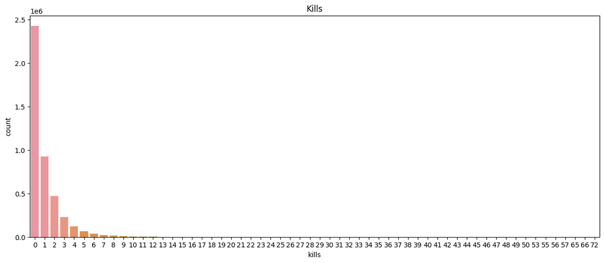

```python
plt.figure(figsize=(15,6))
sns.countplot(data=df, x=df['kills']).set_title('Kills')
plt.show()
```

```python
display(df[df['kills'] > 40].shape)
```

```
(32, 29)
```

```python
df[df['kills'] >= 40].head(5)
```

|  | Id | groupId | matchId | assists | boosts | damageDealt | DBNOs | headshotKills | heals | killPlace | killPoints | kills | killStreaks | longestKill | matchDuration | matchType | maxPlace | numGroups | rankPoints | revives | rideDistance | roadKills | swimDistance | teamKills | vehicleDestroys | walkDistance | weaponsAcquired | winPoints | winPlacePerc |
| --- | --- | --- | --- | --- | --- | --- | --- | --- | --- | --- | --- | --- | --- | --- | --- | --- | --- | --- | --- | --- | --- | --- | --- | --- | --- | --- | --- | --- | --- |
| 156599 | 746aa7eabf7c86 | 5723e7d8250da3 | f900de1ec39fa5 | 21 | 0 | 5480.0 | 0 | 12 | 7 | 4 | 0 | 48 | 6 | 81.9375 | 1798 | normal-solo-fpp | 11 | 11 | 1500 | 0 | 0.0 | 0 | 0.0 | 0 | 0 | 23.703125 | 61 | 0 | 0.700195 |
| 160254 | 15622257cb44e2 | 1a513eeecfe724 | db413c7c48292c | 1 | 0 | 4032.0 | 0 | 40 | 0 | 1 | 1000 | 42 | 5 | 266.2500 | 844 | normal-squad-fpp | 8 | 8 | -1 | 0 | 0.0 | 0 | 0.0 | 1 | 0 | 718.500000 | 16 | 1500 | 1.000000 |
| 334400 | 810f2379261545 | 7f3e493ee71534 | f900de1ec39fa5 | 20 | 0 | 6616.0 | 0 | 13 | 5 | 1 | 0 | 65 | 7 | 73.8750 | 1798 | normal-solo-fpp | 11 | 11 | 1500 | 0 | 0.0 | 0 | 0.0 | 0 | 0 | 1036.000000 | 60 | 0 | 1.000000 |
| 672993 | da31f191ace8ed | ce9a3c4950a8f2 | 17dea22cefe62a | 10 | 0 | 5792.0 | 0 | 5 | 2 | 1 | 0 | 57 | 5 | 104.1875 | 1798 | normal-duo-fpp | 15 | 12 | 1500 | 0 | 0.0 | 0 | 0.0 | 0 | 0 | 24.265625 | 56 | 0 | 1.000000 |
| 770454 | 2ade4369bccd12 | 9f9e64a3db8384 | e024bf51bf1799 | 12 | 0 | 5556.0 | 0 | 7 | 4 | 1 | 0 | 55 | 6 | 74.8125 | 1798 | normal-solo-fpp | 19 | 18 | 1500 | 0 | 0.0 | 0 | 0.0 | 0 | 0 | 85.562500 | 66 | 0 | 1.000000 |

It doesn't look like there are too many outliers. We decide to remove those.

```python
df.drop(df[df['kills'] >= 40].index, inplace=True)
largeKillsDropCount = len(df)
```

```python
print(largeKillsDropCount)
print("Dropped:", potentialCheatsDropCount - largeKillsDropCount)
```

```
4337436
Dropped: 36
```

#### Potential Aim Bot

We will create a new feature 'headshotRate' and plot of it

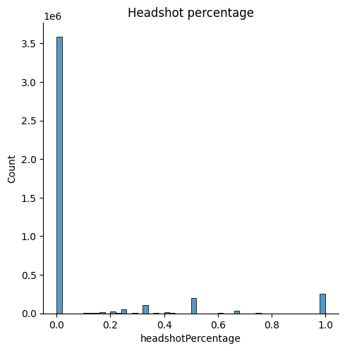

```python
df['headshotPercentage'] = df['headshotKills'] / df['kills']
df['headshotPercentage'] = df['headshotPercentage'].fillna(0)

plt.figure(figsize=(12, 4))
sns.displot(df['headshotPercentage'], bins=50)
plt.title('Headshot percentage')
plt.show()
```

Not every player with 100% headshot has to be cheater. They might be just goog players.n That's why we will remove only players who have more than 10 kills and 100% headshots.

```python
df[(df['headshotKills'] == df['kills']) & (df['kills'] >= 10)].head(5)
```

|  | Id | groupId | matchId | assists | boosts | damageDealt | DBNOs | headshotKills | heals | killPlace | killPoints | kills | killStreaks | longestKill | matchDuration | matchType | maxPlace | numGroups | rankPoints | revives | rideDistance | roadKills | swimDistance | teamKills | vehicleDestroys | walkDistance | weaponsAcquired | winPoints | winPlacePerc | … |
| --- | --- | --- | --- | --- | --- | --- | --- | --- | --- | --- | --- | --- | --- | --- | --- | --- | --- | --- | --- | --- | --- | --- | --- | --- | --- | --- | --- | --- | --- | --- |
| 281570 | ab9d7168570927 | add05ebde0214c | e016a873339c7b | 2 | 3 | 1212.0 | 8 | 10 | 0 | 1 | 0 | 10 | 4 | 159.25 | 1423 | squad-fpp | 27 | 25 | 1564 | 1 | 0.0 | 0 | 0.0 | 0 | 0 | 2940.0 | 5 | 0 | 0.846191 | … |
| 346124 | 044d18fc42fc75 | fc1dbc2df6a887 | 628107d4c41084 | 3 | 5 | 1620.0 | 13 | 11 | 3 | 1 | 1424 | 11 | 2 | 633.50 | 1727 | squad | 27 | 26 | -1 | 3 | 4720.0 | 0 | 0.0 | 0 | 0 | 3422.0 | 8 | 1560 | 1.000000 | … |
| 871244 | e668a25f5488e3 | 5ba8feabfb2a23 | f6e6581e03ba4f | 0 | 4 | 1365.0 | 9 | 13 | 0 | 1 | 1579 | 13 | 2 | 353.75 | 1255 | squad | 27 | 27 | -1 | 0 | 0.0 | 0 | 0.0 | 0 | 0 | 2104.0 | 5 | 1587 | 1.000000 | … |
| 908815 | 566d8218b705aa | a9b056478d71b2 | 3a41552d553583 | 2 | 5 | 1535.0 | 10 | 10 | 3 | 1 | 1393 | 10 | 3 | 533.00 | 1838 | squad-fpp | 28 | 24 | -1 | 0 | 5188.0 | 0 | 0.0 | 2 | 0 | 2760.0 | 7 | 1519 | 0.962891 | … |
| 963463 | 1bd6fd288df4f0 | 90584ffa22fe15 | ba2de992ec7bb8 | 2 | 6 | 1355.0 | 12 | 10 | 2 | 1 | 1543 | 10 | 2 | 277.00 | 1417 | squad | 27 | 26 | -1 | 0 | 1018.0 | 0 | 0.0 | 0 | 0 | 2458.0 | 4 | 1562 | 1.000000 | … |

```python
df.drop(df[(df['headshotKills'] == df['kills']) & (df['kills'] >= 10)].index, inplace=True)
highHSrateDropCount = len(df)
```

```python
print(highHSrateDropCount)
print("Dropped:", largeKillsDropCount - highHSrateDropCount)
```

```
4337412
Dropped: 24
```

Altogether we dropped

```python
print("Dropped:", validStartCount - highHSrateDropCount)
```

```
Dropped: 109553
```

## Train data and test data

Source of data: https://www.kaggle.com/c/pubg-finish-placement-prediction

Our data contains around 4.5 millions rows.

We are going to split it into two sets:

- train set,
- test set

```python
df_train, df_test = split_into_train_test_sets(df, 0.2)
```

### Train data

Brief look at the train data

```python
df_train.head()
```

|  | Id | groupId | matchId | assists | boosts | damageDealt | DBNOs | headshotKills | heals | killPlace | killPoints | kills | killStreaks | longestKill | matchDuration | matchType | maxPlace | numGroups | rankPoints | revives | rideDistance | roadKills | swimDistance | teamKills | vehicleDestroys | walkDistance | weaponsAcquired | winPoints | winPlacePerc | … |
| --- | --- | --- | --- | --- | --- | --- | --- | --- | --- | --- | --- | --- | --- | --- | --- | --- | --- | --- | --- | --- | --- | --- | --- | --- | --- | --- | --- | --- | --- | --- |
| 0 | 7f96b2f878858a | 4d4b580de459be | a10357fd1a4a91 | 0 | 0 | 0.00000 | 0 | 0 | 0 | 60 | 1241 | 0 | 0 | 0.00000 | 1306 | squad-fpp | 28 | 26 | -1 | 0 | 0.000000 | 0 | 0.000000 | 0 | 0 | 244.75 | 1 | 1466 | 0.444336 | … |
| 1 | eef90569b9d03c | 684d5656442f9e | aeb375fc57110c | 0 | 0 | 91.50000 | 0 | 0 | 0 | 57 | 0 | 0 | 0 | 0.00000 | 1777 | squad-fpp | 26 | 25 | 1484 | 0 | 0.004501 | 0 | 11.039062 | 0 | 0 | 1434.00 | 5 | 0 | 0.640137 | … |
| 2 | 1eaf90ac73de72 | 6a4a42c3245a74 | 110163d8bb94ae | 1 | 0 | 68.00000 | 0 | 0 | 0 | 47 | 0 | 0 | 0 | 0.00000 | 1318 | duo | 50 | 47 | 1491 | 0 | 0.000000 | 0 | 0.000000 | 0 | 0 | 161.75 | 2 | 0 | 0.775391 | … |
| 3 | 4616d365dd2853 | a930a9c79cd721 | f1f1f4ef412d7e | 0 | 0 | 32.90625 | 0 | 0 | 0 | 75 | 0 | 0 | 0 | 0.00000 | 1436 | squad-fpp | 31 | 30 | 1408 | 0 | 0.000000 | 0 | 0.000000 | 0 | 0 | 202.75 | 3 | 0 | 0.166748 | … |
| 4 | 315c96c26c9aac | de04010b3458dd | 6dc8ff871e21e6 | 0 | 0 | 100.00000 | 0 | 0 | 0 | 45 | 0 | 1 | 1 | 58.53125 | 1424 | solo-fpp | 97 | 95 | 1560 | 0 | 0.000000 | 0 | 0.000000 | 0 | 0 | 49.75 | 2 | 0 | 0.187500 | … |

```python
df_train.describe()
```

|  | assists | boosts | damageDealt | DBNOs | headshotKills | heals | killPlace | killPoints | kills | killStreaks | longestKill | matchDuration | maxPlace | numGroups | rankPoints | revives | rideDistance | roadKills | swimDistance | teamKills | vehicleDestroys | walkDistance | weaponsAcquired | winPoints | winPlacePerc | headshotPercentage |
| --- | --- | --- | --- | --- | --- | --- | --- | --- | --- | --- | --- | --- | --- | --- | --- | --- | --- | --- | --- | --- | --- | --- | --- | --- | --- | --- |
| count | 3.469847e+06 | 3.469847e+06 | 3.469847e+06 | 3.469847e+06 | 3.469847e+06 | 3.469847e+06 | 3.469847e+06 | 3.469847e+06 | 3.469847e+06 | 3.469847e+06 | 3.469847e+06 | 3.469847e+06 | 3.469847e+06 | 3.469847e+06 | 3.469847e+06 | 3.469847e+06 | 3469847.000 | 3.469847e+06 | 3469847.0 | 3.469847e+06 | 3.469847e+06 | 3.469847e+06 | 3.469847e+06 | 3.469847e+06 | 3.469847e+06 | 3.469847e+06 |
| mean | 2.383901e-01 | 1.131767e+00 | NaN | 6.718607e-01 | 2.316344e-01 | 1.402385e+00 | 4.682020e+01 | 5.064362e+02 | 9.446624e-01 | 5.557087e-01 | NaN | 1.580254e+03 | 4.450200e+01 | 4.304152e+01 | 8.922022e+02 | 1.682633e-01 | NaN | 3.084286e-03 | NaN | 2.396071e-02 | 7.964328e-03 | NaN | 3.734484e+00 | 6.076616e+02 | NaN | 1.054396e-01 |
| std | 5.927108e-01 | 1.727558e+00 | NaN | 1.153240e+00 | 6.027012e-01 | 2.705222e+00 | 2.705407e+01 | 6.284574e+02 | 1.561952e+00 | 7.132730e-01 | NaN | 2.572401e+02 | 2.377867e+01 | 2.321655e+01 | 7.368644e+02 | 4.768281e-01 | NaN | 6.590024e-02 | NaN | 1.680334e-01 | 9.259659e-02 | NaN | 2.415307e+00 | 7.404351e+02 | 0.000000e+00 | 2.628985e-01 |
| min | 0.000000e+00 | 0.000000e+00 | 0.000000e+00 | 0.000000e+00 | 0.000000e+00 | 0.000000e+00 | 1.000000e+00 | 0.000000e+00 | 0.000000e+00 | 0.000000e+00 | 0.000000e+00 | 1.330000e+02 | 2.000000e+00 | 1.000000e+00 | -1.000000e+00 | 0.000000e+00 | 0.000 | 0.000000e+00 | 0.0 | 0.000000e+00 | 0.000000e+00 | 1.000166e-04 | 0.000000e+00 | 0.000000e+00 | 0.000000e+00 | 0.000000e+00 |
| 25% | 0.000000e+00 | 0.000000e+00 | 0.000000e+00 | 0.000000e+00 | 0.000000e+00 | 0.000000e+00 | 2.300000e+01 | 0.000000e+00 | 0.000000e+00 | 0.000000e+00 | 0.000000e+00 | 1.367000e+03 | 2.800000e+01 | 2.700000e+01 | -1.000000e+00 | 0.000000e+00 | 0.000 | 0.000000e+00 | 0.0 | 0.000000e+00 | 0.000000e+00 | 1.722500e+02 | 2.000000e+00 | 0.000000e+00 | 2.143555e-01 | 0.000000e+00 |
| 50% | 0.000000e+00 | 0.000000e+00 | 8.818750e+01 | 0.000000e+00 | 0.000000e+00 | 0.000000e+00 | 4.700000e+01 | 0.000000e+00 | 0.000000e+00 | 0.000000e+00 | 0.000000e+00 | 1.438000e+03 | 3.000000e+01 | 3.000000e+01 | 1.444000e+03 | 0.000000e+00 | 0.000 | 0.000000e+00 | 0.0 | 0.000000e+00 | 0.000000e+00 | 7.340000e+02 | 3.000000e+00 | 0.000000e+00 | 4.680176e-01 | 0.000000e+00 |
| 75% | 0.000000e+00 | 2.000000e+00 | 1.897500e+02 | 1.000000e+00 | 0.000000e+00 | 2.000000e+00 | 7.000000e+01 | 1.174000e+03 | 1.000000e+00 | 1.000000e+00 | 2.231250e+01 | 1.851000e+03 | 4.900000e+01 | 4.700000e+01 | 1.500000e+03 | 0.000000e+00 | 81.625 | 0.000000e+00 | 0.0 | 0.000000e+00 | 0.000000e+00 | 2.009000e+03 | 5.000000e+00 | 1.495000e+03 | 7.500000e-01 | 0.000000e+00 |
| max | 1.700000e+01 | 3.300000e+01 | 4.240000e+03 | 3.900000e+01 | 2.700000e+01 | 7.300000e+01 | 1.010000e+02 | 2.170000e+03 | 3.900000e+01 | 1.800000e+01 | 1.094000e+03 | 2.237000e+03 | 1.000000e+02 | 1.000000e+02 | 5.910000e+03 | 3.200000e+01 | 29424.000 | 1.800000e+01 | 1980.0 | 1.200000e+01 | 5.000000e+00 | 9.984000e+03 | 2.360000e+02 | 2.013000e+03 | 1.000000e+00 | 1.000000e+00 |

### Test data

```python
df_test.head()
```

|  | Id | groupId | matchId | assists | boosts | damageDealt | DBNOs | headshotKills | heals | killPlace | killPoints | kills | killStreaks | longestKill | matchDuration | matchType | maxPlace | numGroups | rankPoints | revives | rideDistance | roadKills | swimDistance | teamKills | vehicleDestroys | walkDistance | weaponsAcquired | winPoints | winPlacePerc | … |
| --- | --- | --- | --- | --- | --- | --- | --- | --- | --- | --- | --- | --- | --- | --- | --- | --- | --- | --- | --- | --- | --- | --- | --- | --- | --- | --- | --- | --- | --- | --- |
| 7 | 311b84c6ff4390 | eaba5fcb7fc1ae | 292611730ca862 | 0 | 0 | 8.539062 | 0 | 0 | 0 | 48 | 1000 | 0 | 0 | 0.000000 | 1967 | solo-fpp | 96 | 92 | -1 | 0 | 2004.0 | 0 | 0.00000 | 0 | 0 | 1089.00 | 6 | 1500 | 0.736816 | … |
| 19 | 71cbdbc3b263e5 | 7b61f74b51906c | a329ac99449ad7 | 0 | 1 | 65.250000 | 0 | 0 | 1 | 48 | 1349 | 0 | 0 | 0.000000 | 1322 | squad-fpp | 30 | 28 | 0 | 0 | 0.0 | 0 | 20.84375 | 0 | 0 | 3310.00 | 3 | 1479 | 0.931152 | … |
| 28 | f9473c4f1cfdc4 | 8483976f3ba230 | 6057f846f3ed12 | 0 | 6 | 345.500000 | 2 | 1 | 1 | 6 | 0 | 4 | 1 | 105.187500 | 1339 | squad-fpp | 28 | 28 | 1339 | 0 | 0.0 | 0 | 0.00000 | 0 | 0 | 3856.00 | 4 | 0 | 0.962891 | … |
| 35 | 47143f942503e0 | e17a8867a393ec | bc2faecb77e5ec | 0 | 0 | 136.875000 | 0 | 0 | 0 | 37 | 0 | 1 | 1 | 22.828125 | 1425 | solo-fpp | 96 | 94 | 1500 | 0 | 0.0 | 0 | 0.00000 | 0 | 0 | 270.75 | 1 | 0 | 0.347412 | … |
| 40 | ffd9e56f13438e | 8df2112760f9e2 | 3f8b160eeee685 | 0 | 1 | 61.906250 | 1 | 0 | 1 | 31 | 0 | 1 | 1 | 48.406250 | 1303 | squad | 26 | 25 | 1472 | 0 | 529.0 | 0 | 0.00000 | 0 | 0 | 327.25 | 2 | 0 | 0.320068 | … |

```python
df_test.describe()
```

|  | assists | boosts | damageDealt | DBNOs | headshotKills | heals | killPlace | killPoints | kills | killStreaks | longestKill | matchDuration | maxPlace | numGroups | rankPoints | revives | rideDistance | roadKills | swimDistance | teamKills | vehicleDestroys | walkDistance | weaponsAcquired | winPoints | winPlacePerc | headshotPercentage |
| --- | --- | --- | --- | --- | --- | --- | --- | --- | --- | --- | --- | --- | --- | --- | --- | --- | --- | --- | --- | --- | --- | --- | --- | --- | --- | --- |
| count | 867565.000000 | 867565.000000 | 867565.000 | 867565.000000 | 867565.000000 | 867565.000000 | 867565.000000 | 867565.000000 | 867565.000000 | 867565.000000 | 867565.000000 | 867565.000000 | 867565.000000 | 867565.000000 | 867565.000000 | 867565.000000 | 867565.0000 | 867565.000000 | 867565.0 | 867565.000000 | 867565.000000 | 867565.0000 | 867565.000000 | 867565.000000 | 867565.000000 | 867565.000000 |
| mean | 0.238522 | 1.131575 | NaN | 0.675299 | 0.231425 | 1.392457 | 46.833276 | 515.209303 | 0.940653 | 0.556460 | NaN | 1580.545062 | 44.283254 | 42.829447 | 880.640411 | 0.169433 | NaN | 0.003108 | NaN | 0.023577 | 0.008021 | NaN | 3.720321 | 618.834212 | NaN | 0.105714 |
| std | 0.587974 | 1.724802 | NaN | 1.147718 | 0.600599 | 2.686267 | 27.049054 | 629.828682 | 1.542626 | 0.714488 | NaN | 257.405717 | 23.582118 | 23.000790 | 738.636207 | 0.476911 | NaN | 0.065496 | NaN | 0.165959 | 0.093134 | NaN | 2.352038 | 742.563683 | 0.000000 | 0.263227 |
| min | 0.000000 | 0.000000 | 0.000 | 0.000000 | 0.000000 | 0.000000 | 1.000000 | 0.000000 | 0.000000 | 0.000000 | 0.000000 | 312.000000 | 2.000000 | 1.000000 | -1.000000 | 0.000000 | 0.0000 | 0.000000 | 0.0 | 0.000000 | 0.000000 | 0.0001 | 0.000000 | 0.000000 | 0.000000 | 0.000000 |
| 25% | 0.000000 | 0.000000 | 0.000 | 0.000000 | 0.000000 | 0.000000 | 23.000000 | 0.000000 | 0.000000 | 0.000000 | 0.000000 | 1367.000000 | 28.000000 | 27.000000 | -1.000000 | 0.000000 | 0.0000 | 0.000000 | 0.0 | 0.000000 | 0.000000 | 171.7500 | 2.000000 | 0.000000 | 0.214355 | 0.000000 |
| 50% | 0.000000 | 0.000000 | 88.750 | 0.000000 | 0.000000 | 0.000000 | 47.000000 | 0.000000 | 0.000000 | 0.000000 | 0.000000 | 1438.000000 | 30.000000 | 30.000000 | 1438.000000 | 0.000000 | 0.0000 | 0.000000 | 0.0 | 0.000000 | 0.000000 | 731.5000 | 3.000000 | 0.000000 | 0.466797 | 0.000000 |
| 75% | 0.000000 | 2.000000 | 189.625 | 1.000000 | 0.000000 | 2.000000 | 70.000000 | 1178.000000 | 1.000000 | 1.000000 | 22.296875 | 1851.000000 | 49.000000 | 47.000000 | 1500.000000 | 0.000000 | 59.6875 | 0.000000 | 0.0 | 0.000000 | 0.000000 | 2011.0000 | 5.000000 | 1497.000000 | 0.750000 | 0.000000 |
| max | 17.000000 | 23.000000 | 4080.000 | 26.000000 | 23.000000 | 80.000000 | 100.000000 | 2154.000000 | 38.000000 | 11.000000 | 1000.000000 | 2218.000000 | 100.000000 | 100.000000 | 5820.000000 | 39.000000 | 28448.0000 | 11.000000 | 1960.0 | 4.000000 | 3.000000 | 9992.0000 | 95.000000 | 2002.000000 | 1.000000 | 1.000000 |

### Data Fields Descriptions

```python
print(df_types)
```

```
         Data field                                        Description     Type
0                Id                                        Player's Id   object
1           groupId              ID to identify a group within a match   object
2           matchId                               ID to identify match   object
3         matchType  String identifing the game mode that the data ...   object
4           assists  Number of enemy players this player damaged th...    int64
5            boosts                         Number of boost items used    int64
6       damageDealt                                 Total damage dealt  float64
7             DBNOs                    Number of enemy players knocked    int64
8     headshotKills      Number of enemy players killed with headshots    int64
9             heals                       Number of healing items used    int64
10        killPlace  Ranking in match of number of enemy players ki...    int64
11       killPoints             Kills-based external ranking of player    int64
12      killStreaks  Max number of enemy players killed in a short ...    int64
13            kills                     Number of enemy players killed    int64
14      longestKill  Longest distance between player and player kil...  float64
15    matchDuration                       Duration of match in seconds    int64
16       rankPoints                         Elo-like ranking of player    int64
17          revives      Number of times this player revived teammates    int64
18     rideDistance  Total distance traveled in vehicles measured i...    int64
19        roadKills                 Number of kills while in a vehicle    int64
20     swimDistance  Total distance traveled by swimming measured i...  float64
21        teamKills      Number of times this player killed a teammate    int64
22  vehicleDestroys                       Number of vehicles destroyed    int64
23     walkDistance  Total distance traveled on foot measured in me...  float64
24  weaponsAcquired                        Number of weapons picked up    int64
25        winPoints               Win-based external ranking of player    int64
26        numGroups     Number of groups we have data for in the match    int64
27         maxPlace      Worst placement we have data for in the match    int64
28     winPlacePerc                           The target of prediction  float64
```

```python
print(df_train["matchType"].unique())
```

```
['squad-fpp' 'duo' 'solo-fpp' 'squad' 'duo-fpp' 'solo' 'normal-squad-fpp'
 'normal-solo-fpp' 'normal-duo-fpp' 'normal-duo' 'normal-squad'
 'normal-solo']
```

Players playing solo-match have their own placement, while the players from the same group share the same placement.

## Looking for best strategy

### Correlation of feature

A correlation matrix is a table showing correlation coefficients between variables. Each cell in the table shows the correlation between two variables.

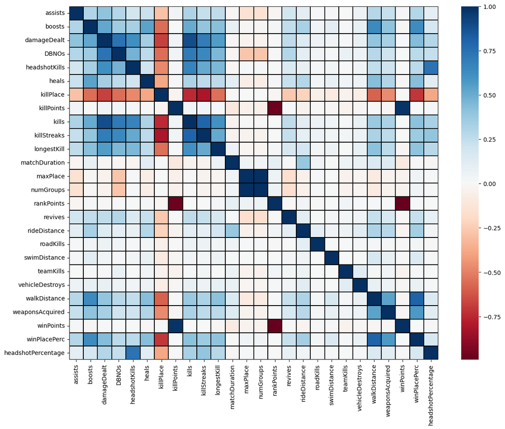

```python
# We do not use columns containing Id and matchType. Only numerical values.
cols_to_drop = ['Id', 'groupId', 'matchId', 'matchType']
cols_to_fit = [col for col in df.columns if col not in cols_to_drop]
corr = df[cols_to_fit].corr()

plt.figure(figsize=(14,11))
sns.heatmap(
    corr,
    xticklabels=corr.columns.values,
    yticklabels=corr.columns.values,
    linecolor='black',
    linewidths=0.1,
    cmap="RdBu"
)
plt.show()
```

As we can see there are some pairs of value that are highly correlated. It is possible that the highly correlated variables such as might be the most important features in predicting winPlacePerc.

Pairs with correlation >= 0.45:

```python
corr_pairs = corr.unstack().sort_values(ascending=False).drop_duplicates()
corr_pairs[corr_pairs >= 0.45]
```

```
assists             assists          1.000000
maxPlace            numGroups        0.998236
winPoints           killPoints       0.983452
damageDealt         kills            0.887425
winPlacePerc        walkDistance     0.810390
kills               killStreaks      0.803082
damageDealt         DBNOs            0.737639
headshotPercentage  headshotKills    0.737256
kills               DBNOs            0.709956
killStreaks         damageDealt      0.701581
kills               headshotKills    0.671712
killStreaks         DBNOs            0.644889
boosts              walkDistance     0.637142
winPlacePerc        boosts           0.632603
headshotKills       damageDealt      0.610699
kills               longestKill      0.603579
weaponsAcquired     winPlacePerc     0.573229
damageDealt         longestKill      0.563338
weaponsAcquired     walkDistance     0.537947
boosts              heals            0.532803
                    damageDealt      0.521317
killStreaks         longestKill      0.512229
                    headshotKills    0.511868
kills               boosts           0.502377
DBNOs               headshotKills    0.470472
dtype: float64
```

#### Highlt correlated

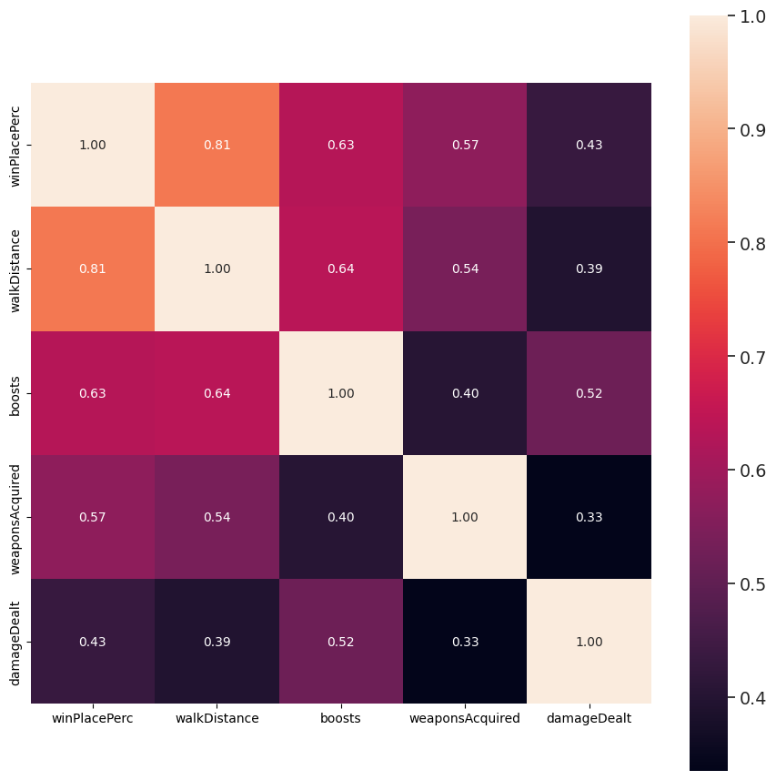

```python
f,ax = plt.subplots(figsize=(11, 11))
cols = df.corr().nlargest(5, 'winPlacePerc')['winPlacePerc'].index
cm = np.corrcoef(df[cols].values.T)
sns.set(font_scale=1.25)
hm = sns.heatmap(cm, cbar=True, annot=True, square=True, fmt='.2f', annot_kws={'size': 10}, yticklabels=cols.values, xticklabels=cols.values)
plt.show()
```

### Impact of kills made on final position

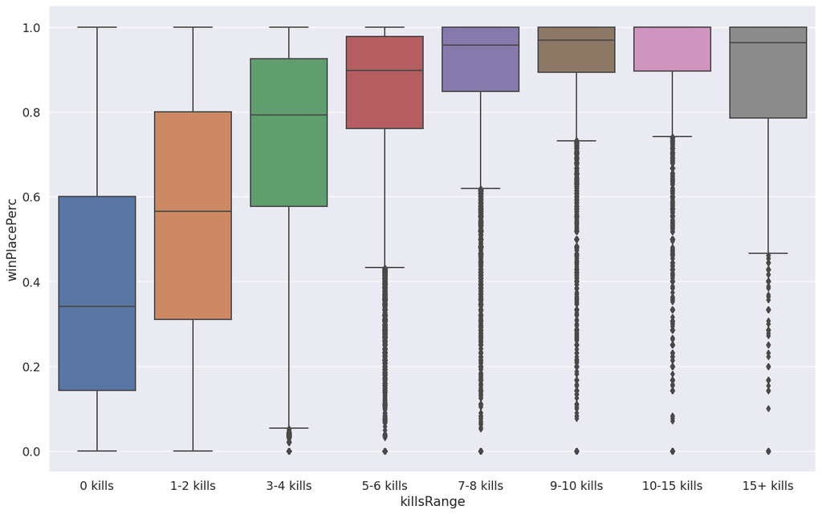

```python
df['killsRange'] = pd.cut(df['kills'], [-1, 0, 2, 4, 6, 8, 10, 15, 100],
                                            labels=['0 kills','1-2 kills', '3-4 kills', '5-6 kills',
                                                    '7-8 kills', '9-10 kills','10-15 kills', '15+ kills'])
plt.figure(figsize=(16,10))
sns.boxplot(x='killsRange', y='winPlacePerc', data=df)
df.drop(['killsRange'],axis=1,inplace=True)
```

### Boosts and heals importance

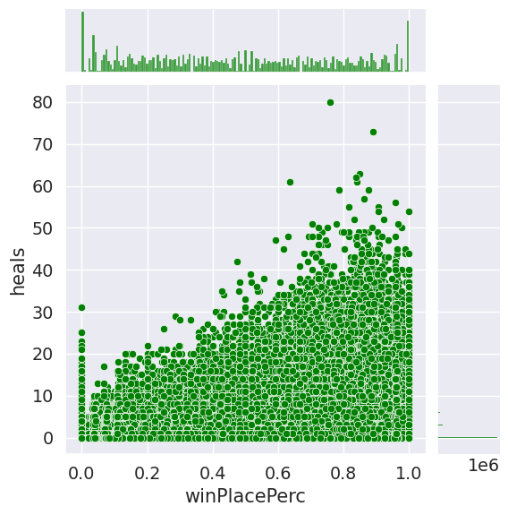

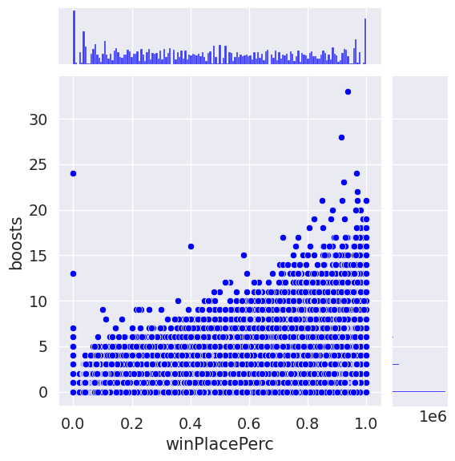

```python
sns.jointplot(x='winPlacePerc', y='heals', data=df, color='green')
sns.jointplot(x='winPlacePerc', y='boosts', data=df, color='blue')
plt.show()
```

## New Features

Now we will consider some other options.

### Players in match

This features will let as know how many people are in a match. Thanks to that we can normalize some features.

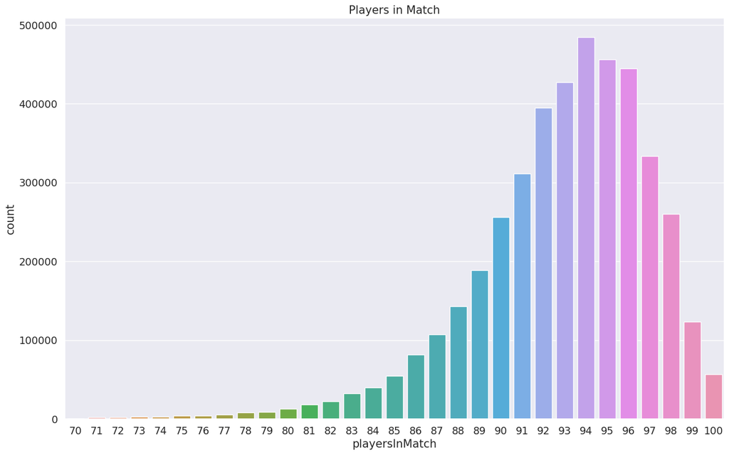

```python
df['playersInMatch'] = df.groupby('matchId')['matchId'].transform('count')
plt.figure(figsize=(16,10))
sns.countplot(x=df[df['playersInMatch']>=70]['playersInMatch'])
plt.title('Players in Match')
plt.show()
```

Most of the matches are nearly full.

#### Normalization

Based on the "playersInMatch" feature we can create (or change) a lot of others to normalize their values. Since the number of players in game is not const and when there are 100players in the game it might be easier to find someone we can create the "killsNorm", "damageDealtNorm"

```python
df['killsNorm'] = df['kills']*((100-df['playersInMatch'])/100 + 1)
df['damageDealtNorm'] = df['damageDealt']*((100-df['playersInMatch'])/100 + 1)
df['assistsNorm'] = df['assists']*((100-df['playersInMatch'])/100 + 1)
df['DBNOsNorm'] = df['DBNOs']*((100-df['playersInMatch'])/100 + 1)

df[['playersInMatch', 'kills', 'killsNorm', 'damageDealt', 'damageDealtNorm', 'assists', 'assistsNorm', 'DBNOs', 'DBNOsNorm']].head()
```

|  | playersInMatch | kills | killsNorm | damageDealt | damageDealtNorm | assists | assistsNorm | DBNOs | DBNOsNorm |
| --- | --- | --- | --- | --- | --- | --- | --- | --- | --- |
| 0 | 94 | 0 | 0.00 | 0.00000 | 0.000000 | 0 | 0.00 | 0 | 0.0 |
| 1 | 90 | 0 | 0.00 | 91.50000 | 100.650000 | 0 | 0.00 | 0 | 0.0 |
| 2 | 93 | 0 | 0.00 | 68.00000 | 72.760000 | 1 | 1.07 | 0 | 0.0 |
| 3 | 91 | 0 | 0.00 | 32.90625 | 35.867812 | 0 | 0.00 | 0 | 0.0 |
| 4 | 94 | 1 | 1.06 | 100.00000 | 106.000000 | 0 | 0.00 | 0 | 0.0 |

### Total Distance

```python
df['totalDistance'] = df['rideDistance'] + df['swimDistance'] + df['walkDistance']
df['totalDistance'].describe()
```

```
count    4.337412e+06
mean              NaN
std               NaN
min      1.000166e-04
25%      1.755000e+02
50%      8.560000e+02
75%      2.770000e+03
max      3.030400e+04
Name: totalDistance, dtype: float64
```

## New Features Evaluation |For 21.04

We will create new features and analyze their impact. To do that we will create a simple linear model for each set of features and compare them.

```python
from sklearn.linear_model import LinearRegression, Lasso, ElasticNet
from sklearn.neural_network import MLPRegressor
from sklearn.metrics import mean_absolute_error, mean_squared_error, explained_variance_score
from sklearn.model_selection import cross_val_score, GridSearchCV
from sklearn.feature_selection import SelectFromModel
from sklearn.ensemble import RandomForestRegressor
```

### Linear Regression

```python
results = []
def resultsAppend(name,val):
    results.append({'name': name, 'error': val} )
```

```python
colsToDrop = ['Id','groupId','matchId','matchType']
colsNorm = ['killsNorm','damageDealtNorm','assistsNorm','DBNOsNorm']
colsNoNorm = ['kills', 'damageDealt','assists', 'DBNOs']
```

```python
def scoreMetrices(true,predicted):
      return (mean_squared_error(true,predicted),)
```

```python
def tryDataLinear(data):
    random.seed(42)
    data_train,data_test = split_into_train_test_sets(data)
    data_train = data_train.drop(colsToDrop,axis=1)
    data_test = data_test.drop(colsToDrop,axis=1)

    model = LinearRegression(n_jobs=-1)
    model.fit(data_train.drop(['winPlacePerc'],axis=1),data_train['winPlacePerc'])
    pred = model.predict(data_test.drop(['winPlacePerc'],axis=1))
    return scoreMetrices(data_test['winPlacePerc'],pred)
```

We are checking already added features.

```python
results = []
resultsAppend('default', tryDataLinear(df[defaultCols]))
resultsAppend('normalized w/', tryDataLinear(df[defaultCols + colsNorm]))
resultsAppend('normalized w/o', tryDataLinear(df[defaultCols + colsNorm].drop(colsNoNorm,axis=1)))
resultsAppend('total distance', tryDataLinear(df[defaultCols + ['totalDistance']]))
resultsAppend('hs percentage', tryDataLinear(df[defaultCols + ['headshotPercentage']]))
```

We are adding new features.

```python
df['items'] = df['heals'] + df['boosts']
resultsAppend('items', tryDataLinear(df[defaultCols+['items']]))
```

```python
df['walkDistancePerKill'] = df['walkDistance'] / df['kills']
df['walkDistancePerKill'].fillna(0, inplace=True)
df['walkDistancePerKill'].replace(np.inf, 0, inplace=True)
resultsAppend('walk dist per kill', tryDataLinear(df[defaultCols+['walkDistancePerKill']]))
```

```python
resultsAppend('all', tryDataLinear(df))
```

```python
gc.collect()
pd.DataFrame(results)
```

|  | name | error |
| --- | --- | --- |
| 0 | default | 0.015742 |
| 1 | normalized w/ | 0.015623 |
| 2 | normalized w/o | 0.015760 |
| 3 | total distance | 0.015742 |
| 4 | hs percentage | 0.015472 |
| 5 | items | 0.015742 |
| 6 | walk dist per kill | 0.015717 |
| 7 | all | 0.014732 |

We can see that all added features separately have little to no effect on MSE value but combined they decrease error value.

### Random Forrest

We are going to create simple Random Forrest Regressor model on all added features and extract their importances.

```python
def tryDataRandomFor(data):
    random.seed(42)
    data_train,data_test = split_into_train_test_sets(data)
    data_train = data_train.drop(colsToDrop,axis=1)
    data_test = data_test.drop(colsToDrop,axis=1)

    model = RandomForestRegressor(max_depth=20, random_state = 123, n_estimators=50,max_features='sqrt',verbose=1,n_jobs=-1)
    model.fit(data_train.drop(['winPlacePerc'],axis=1),data_train['winPlacePerc'])
    print("ready, predicting...")
    pred = model.predict(data_test.drop(['winPlacePerc'],axis=1))
    gc.collect()
    print(model.feature_importances_)
    return scoreMetrices(data_test['winPlacePerc'],pred),model.feature_importances_
```

```python
err, importances = tryDataRandomFor(df)
err
```

```
[Parallel(n_jobs=-1)]: Using backend ThreadingBackend with 4 concurrent workers.
[Parallel(n_jobs=-1)]: Done  42 tasks      | elapsed:  1.9min
[Parallel(n_jobs=-1)]: Done  50 out of  50 | elapsed:  2.2min finished
[Parallel(n_jobs=4)]: Using backend ThreadingBackend with 4 concurrent workers.
```

```
ready, predicting...
```

```
[Parallel(n_jobs=4)]: Done  42 tasks      | elapsed:    4.4s
[Parallel(n_jobs=4)]: Done  50 out of  50 | elapsed:    5.1s finished
```

```
[1.96188931e-03 9.49342500e-02 8.05289155e-03 1.63502346e-03
 9.24685222e-04 3.06395964e-02 2.07024049e-01 1.17194793e-03
 5.31039372e-03 2.56074178e-03 1.81659757e-02 1.54229028e-02
 8.48489584e-03 9.35906241e-03 2.18529340e-03 4.49193914e-04
 1.48008009e-02 3.14675069e-05 8.81232136e-04 1.81357033e-04
 5.72665215e-05 2.22661189e-01 6.45127010e-02 1.47509165e-03
 3.80463817e-03 6.97336086e-03 9.41051445e-03 1.15130708e-02
 1.87083502e-03 3.32803454e-03 1.58965349e-01 4.45503803e-02
 4.66999179e-02]
```

```
0.007329174284615545
```

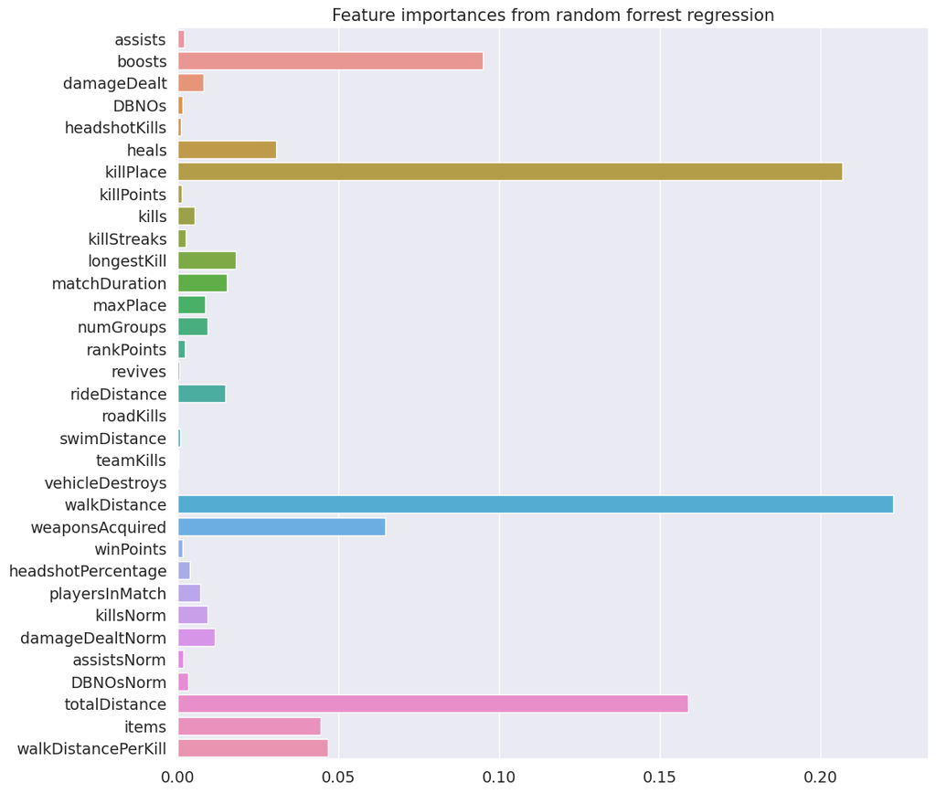

|  | importance |
| --- | --- |
| walkDistance | 0.222661 |
| killPlace | 0.207024 |
| totalDistance | 0.158965 |
| boosts | 0.094934 |
| weaponsAcquired | 0.064513 |
| walkDistancePerKill | 0.046700 |
| items | 0.044550 |
| heals | 0.030640 |
| longestKill | 0.018166 |
| matchDuration | 0.015423 |
| rideDistance | 0.014801 |
| damageDealtNorm | 0.011513 |
| killsNorm | 0.009411 |
| numGroups | 0.009359 |
| maxPlace | 0.008485 |
| damageDealt | 0.008053 |
| playersInMatch | 0.006973 |
| kills | 0.005310 |
| headshotPercentage | 0.003805 |
| DBNOsNorm | 0.003328 |
| killStreaks | 0.002561 |
| rankPoints | 0.002185 |
| assists | 0.001962 |
| assistsNorm | 0.001871 |
| DBNOs | 0.001635 |
| winPoints | 0.001475 |
| killPoints | 0.001172 |
| headshotKills | 0.000925 |
| swimDistance | 0.000881 |
| revives | 0.000449 |
| teamKills | 0.000181 |
| vehicleDestroys | 0.000057 |
| roadKills | 0.000031 |

```python
forest_importances = pd.DataFrame(importances, index = list(df.drop(['winPlacePerc']+colsToDrop,axis=1).columns),columns=["importance"])

plt.figure(figsize=(12,12))
ax = sns.barplot(y =list(df.drop(['winPlacePerc']+colsToDrop,axis=1).columns), x = importances)
plt.title('Feature importances from random forrest regression')
plt.show()
forest_importances.sort_values(by=['importance'],ascending=False)
```

### Multi-Layer Perceptron

We are adding a MLP model in order to check how well it performs compared to previously created models.

```python
def tryDataMLP(data):
    random.seed(13)
    data_train,data_test = split_into_train_test_sets(data)
    data_train = data_train.drop(colsToDrop,axis=1)
    data_test = data_test.drop(colsToDrop,axis=1)

    model = MLPRegressor(hidden_layer_sizes=(100,50),verbose=True)

    model.fit(data_train.drop(['winPlacePerc'],axis=1),data_train['winPlacePerc'])
    pred = model.predict(data_test.drop(['winPlacePerc'],axis=1))
    gc.collect()
    return scoreMetrices(data_test['winPlacePerc'],pred)
```

```python
tryDataMLP(df)
```

```
Iteration 1, loss = 12.30300443
Iteration 2, loss = 0.44146175
Iteration 3, loss = 0.03553147
Iteration 4, loss = 0.00599401
Iteration 5, loss = 0.00521973
Iteration 6, loss = 0.00474776
Iteration 7, loss = 0.00444030
Iteration 8, loss = 0.00440045
Iteration 9, loss = 0.00439647
Iteration 10, loss = 0.00438827
Iteration 11, loss = 0.00438111
Iteration 12, loss = 0.00437673
Iteration 13, loss = 0.00437625
Iteration 14, loss = 0.00437320
Iteration 15, loss = 0.00437158
Iteration 16, loss = 0.00436945
Iteration 17, loss = 0.00437131
Iteration 18, loss = 0.00437096
Training loss did not improve more than tol=0.000100 for 10 consecutive epochs. Stopping.
```

```
0.008658087505028349
```

The MSE value is comparable to Random Forrest Regressor error value. We also checked wider and deeper MLP models but no significant decrease in error value was achived.

### LightGBM | For 26.04

Next we will use tree based Light Gradient Boosting Machine model to see if we can still increase the performance.

LightGBM, unlike standard gradient boosting machines, uses growth in the vertical direction (leaf-wise) instead of growth in the horizontal direction (level-wise). Thanks to it model increases training speed and accuracy of received results for big volumes of data.

```python
def tryDataLGBM(data):
    # random.seed(13)
    data_train, data_test = split_into_train_test_sets(data)
    data_train = data_train.drop(colsToDrop, axis=1)
    data_test = data_test.drop(colsToDrop, axis=1)

    x_train = data_train.drop(['winPlacePerc'],axis=1)
    y_train = data_train['winPlacePerc']
    x_test = data_test.drop(['winPlacePerc'],axis=1)
    y_test = data_test['winPlacePerc']

    # laoding data
    lgb_train = lgb.Dataset(x_train, y_train)
    lgb_eval = lgb.Dataset(x_test, y_test, reference=lgb_train)

    params = {
        'objective': 'regression',    # defines regression model
        'num_leaves': 50,             # max number of leafs in one tree
        'learning_rate': 0.03,        # shrinkage rate - rate of dropped trees
        'min_split_gain': 0.0001,     # min gain to perform split
        'bagging_fraction': 0.9,      # randomly select subset of features on each iteration (without resampling)
        'min_data_in_leaf': 1000,     # min data in leaf
        'lambda_l2': 9,               # L2 regularization
        'metric': {'l2','l1'},        # list l1 (absolute loss) and l2 (square loss) metrics
    }

    # fitting the model
    # parameters:
    # num_boost_round - maximum number of boosting iterations
    # early_stopping - stopping after X iterations without notable increase
    # log_evaluation - write down evaluation results every X iterations
    model = lgb.train(params,
                      train_set=lgb_train,
                      valid_sets=lgb_eval,
                      num_boost_round = 1000,
                      callbacks=[lgb.early_stopping(stopping_rounds=30),
                                lgb.log_evaluation(period=100)])

    # prediction
    pred = model.predict(x_test)

    # accuracy check
    mse = mean_squared_error(y_test, pred)
    rmse = mse**(0.5)
    print("MSE: %.8f" % mse)
    print("RMSE: %.8f" % rmse)

    feature_importances_ = (model.feature_importance() / sum(model.feature_importance()))

    return scoreMetrices(data_test['winPlacePerc'], pred), feature_importances_
```

```python
err, importances = tryDataLGBM(df)
print("ERR: %f" % err)
```

```
[LightGBM] [Warning] Auto-choosing row-wise multi-threading, the overhead of testing was 0.240409 seconds.
You can set `force_row_wise=true` to remove the overhead.
And if memory is not enough, you can set `force_col_wise=true`.
[LightGBM] [Info] Total Bins 4510
[LightGBM] [Info] Number of data points in the train set: 3469771, number of used features: 33
[LightGBM] [Info] Start training from score 0.482656
Training until validation scores don't improve for 30 rounds
[100]	valid_0's l1: 0.0652805	valid_0's l2: 0.00790295
[200]	valid_0's l1: 0.0587909	valid_0's l2: 0.00673547
[300]	valid_0's l1: 0.0574327	valid_0's l2: 0.00645155
[400]	valid_0's l1: 0.0568812	valid_0's l2: 0.00633338
[500]	valid_0's l1: 0.0565826	valid_0's l2: 0.00627215
[600]	valid_0's l1: 0.0563721	valid_0's l2: 0.00623257
[700]	valid_0's l1: 0.0562298	valid_0's l2: 0.00620531
[800]	valid_0's l1: 0.0561374	valid_0's l2: 0.00618638
[900]	valid_0's l1: 0.0560596	valid_0's l2: 0.00617229
[1000]	valid_0's l1: 0.0559976	valid_0's l2: 0.00616046
Did not meet early stopping. Best iteration is:
[1000]	valid_0's l1: 0.0559976	valid_0's l2: 0.00616046
MSE: 0.00616046
RMSE: 0.07848859
ERR: 0.006160
```

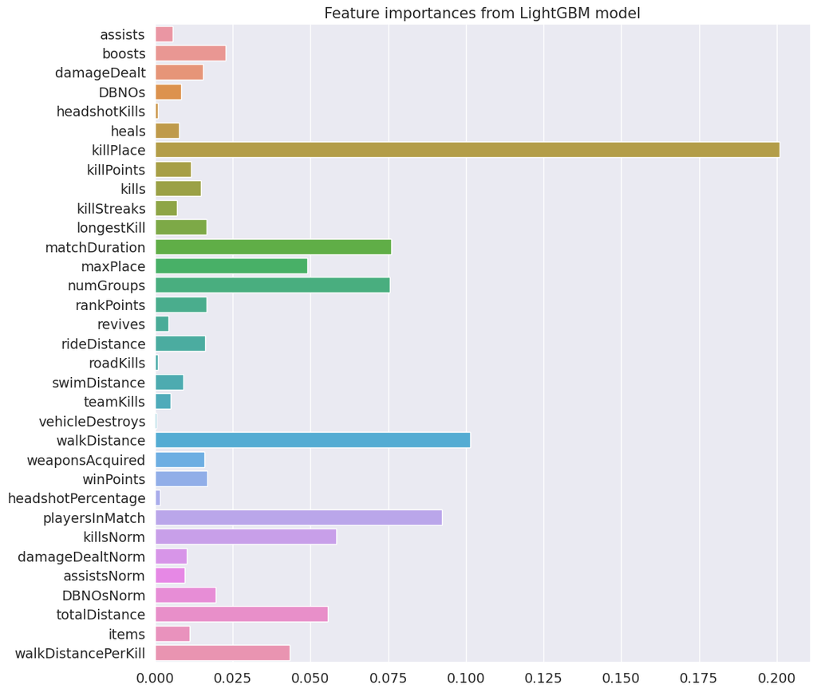

|  | importance |
| --- | --- |
| killPlace | 0.200878 |
| walkDistance | 0.101449 |
| playersInMatch | 0.092245 |
| matchDuration | 0.075959 |
| numGroups | 0.075571 |
| killsNorm | 0.058204 |
| totalDistance | 0.055571 |
| maxPlace | 0.049041 |
| walkDistancePerKill | 0.043245 |
| boosts | 0.022755 |
| DBNOsNorm | 0.019429 |
| winPoints | 0.016694 |
| rankPoints | 0.016612 |
| longestKill | 0.016490 |
| rideDistance | 0.016184 |
| weaponsAcquired | 0.015980 |
| damageDealt | 0.015367 |
| kills | 0.014735 |
| killPoints | 0.011571 |
| items | 0.011020 |
| damageDealtNorm | 0.010265 |
| assistsNorm | 0.009469 |
| swimDistance | 0.009041 |
| DBNOs | 0.008347 |
| heals | 0.007694 |
| killStreaks | 0.007061 |
| assists | 0.005755 |
| teamKills | 0.005102 |
| revives | 0.004388 |
| headshotPercentage | 0.001612 |
| roadKills | 0.001000 |
| headshotKills | 0.000816 |
| vehicleDestroys | 0.000449 |

```python
LGBM_importances = pd.DataFrame(importances, index = list(df.drop(['winPlacePerc']+colsToDrop,axis=1).columns),columns=["importance"])

plt.figure(figsize=(12,12))
ax = sns.barplot(y =list(df.drop(['winPlacePerc']+colsToDrop,axis=1).columns), x = importances)
plt.title('Feature importances from LightGBM model')
plt.show()
LGBM_importances.sort_values(by=['importance'],ascending=False)
```

Model is defined in sklearn.tree namespace

```python
from sklearn.tree import DecisionTreeRegressor
```

While defining model, only parameter that we provide is maximal depth of trees - we use 10, as it significantly improves accuracy of algorithm.

```python
def tryDataGBRT(data):
    data_train,data_test = split_into_train_test_sets(data)
    data_train = data_train.drop(colsToDrop,axis=1)
    data_test = data_test.drop(colsToDrop,axis=1)
    model = DecisionTreeRegressor(max_depth=10)
    model.fit(data_train.drop(['winPlacePerc'],axis=1),data_train['winPlacePerc'])
    pred = model.predict(data_test.drop(['winPlacePerc'],axis=1))
    gc.collect()
    return scoreMetrices(data_test['winPlacePerc'],pred)
```

```python
err = tryDataGBRT(df)
print("ERR: %f" % err)
```

```
ERR: 0.009002
```

### XGboost

XGBoost is an open-source library providing implementation of gradient boosted decision trees algorithm. This library provies regression model, we will use model from scikit-learn wrapper classes.

First of all we need to import the necessary library and valid regression model from it

```python
import xgboost
from xgboost import XGBRegressor
```

XGBRegressor is a class from scikit-learn, it is parameterizable. We specify the following parameters:

```python
def tryDataXGBoost(data):
    data_train,data_test = split_into_train_test_sets(data)
    data_train = data_train.drop(colsToDrop,axis=1)
    data_test = data_test.drop(colsToDrop,axis=1)
    model = XGBRegressor(n_estimators=100, max_depth=5, eta=0.1, subsample=1, colsample_bytree=1)
    model.fit(data_train.drop(['winPlacePerc'],axis=1),data_train['winPlacePerc'])
    pred = model.predict(data_test.drop(['winPlacePerc'],axis=1))
    gc.collect()
    return scoreMetrices(data_test['winPlacePerc'],pred)
```

```python
err = tryDataXGBoost(df)
print("ERR: %f" % err)
```

```
ERR: 0.006813
```

## Conclusion

Summarising we collected all of the attained mean square errors for each model in a table below.

[figure not shown]